Coding Essentials for Astronomers

# Time Series Fitting: Exoplanet Transits

## Introduction

Time series data—measurements collected sequentially over time—are fundamental to astronomy. Stellar brightness variations, radial velocity measurements, and telescope tracking data all form time series that reveal the physics of celestial objects and their environments. This lecture focuses on a particularly elegant application: detecting and characterizing exoplanets through transit photometry.

We'll focus primarily on transit photometry, which detects periodic dimming as a planet crosses the stellar disk. For context, we'll also discuss radial velocity (RV) methods, which measure stellar wobble induced by an orbiting planet—a natural extension of the binary star systems we studied in the last lecture. Both methods produce time series data, but they require very different observational techniques and analysis approaches. Radial velocity demands high-resolution spectroscopy to measure Doppler shifts with sub-m/s precision, while transit photometry—our main focus—requires precise photometry to detect fractional brightness changes at the parts-per-million level.

The transit method has revolutionized exoplanet science. NASA's Kepler mission alone discovered thousands of confirmed exoplanets by monitoring 150,000 stars continuously for four years, detecting periodic brightness dips as planets crossed in front of their host stars. This lecture will teach you the curve-fitting techniques needed to analyze transit light curves, extract physical parameters, and characterize distant planetary systems. You'll learn how radial velocity measurements reveal planetary masses and the observational challenges of detecting Earth-like planets, why the discovery of "hot Jupiters" in the 1990s shocked astronomers, and the geometric and physical principles underlying transit photometry.

We'll cover how to fit transit models to data using `scipy.optimize`, the Box Least Squares (BLS) algorithm for finding orbital periods in noisy time series, and phase folding techniques to enhance signal-to-noise ratios. By the end, you'll have hands-on experience with the same techniques professional astronomers use to discover and characterize exoplanets, deriving complete physical characterizations including radius, orbital distance, and temperature from raw photometric time series.

```python
# Import required libraries
import numpy as np
import matplotlib.pyplot as plt
from scipy import optimize
from astropy import units as u
from astropy import constants as const

# Define solar and planetary constants using astropy
M_sun = const.M_sun.value  # kg
R_sun = const.R_sun.value  # m
G = const.G.value  # m^3 kg^-1 s^-2
M_earth = const.M_earth.value  # kg
R_earth = const.R_earth.value  # m
M_jupiter = const.M_jup.value  # kg
R_jupiter = const.R_jup.value  # m

# Set random seed for reproducibility
np.random.seed(42)

# Configure matplotlib for better-looking plots
plt.rcParams['figure.dpi'] = 100
plt.rcParams['font.size'] = 10
```

## Understanding the Precision Requirements: The Hot Jupiter Surprise

Before diving into transits, let's understand why exoplanet detection seemed impossible in the early 1990s. Astronomers expected planetary systems to resemble our Solar System—giant planets far from their stars (Jupiter at 5 AU, Saturn at 10 AU) and small rocky planets closer in. Based on Solar System architecture, detecting planets would require extraordinarily difficult measurements.

Let's use the mass function from Lecture 18 to understand the challenge. Recall that for a binary system with masses $M_1$ and $M_2$, the radial velocity amplitude is:

$$K_1 = \left(\frac{2\pi G}{P}\right)^{1/3} \frac{M_2 \sin i}{(M_1 + M_2)^{2/3}}$$

Now let's apply this to a planet-star system. We substitute $M_1 = M_\star$ (the star) and $M_2 = M_p$ (the planet). Since $M_\star \gg M_p$ (the star is much more massive), we can approximate $(M_\star + M_p)^{2/3} \approx M_\star^{2/3}$ in the denominator. This gives us the radial velocity amplitude for exoplanet detection:

$$K \approx \left(\frac{2\pi G}{P}\right)^{1/3} \frac{M_p \sin i}{M_\star^{2/3}}$$

This formula reveals two key insights. First, $K$ scales linearly with planet mass $M_p$—more massive planets produce larger wobbles. Second, $K$ scales as $P^{-1/3}$—planets on shorter-period, tighter orbits produce larger signals. Combining these effects, massive planets close to their stars are dramatically easier to detect than small distant ones.

Let's calculate how much Earth makes the Sun wobble. We can directly use the RV amplitude formula with Earth-Sun parameters:

```python
# System parameters (Earth-Sun, edge-on orbit)
m_star = 1.0 * M_sun  # Star mass (Sun)
m_planet = 1.0 * M_earth  # Planet mass (Earth)
period = (365.25 * u.day).to(u.s).value  # Orbital period in seconds
sin_i = 1.0  # Assume edge-on orbit (maximum signal)

# Calculate RV amplitude directly from the formula
# K ≈ (2πG/P)^(1/3) × (M_p sin i) / M_star^(2/3)
K = (2 * np.pi * G / period)**(1/3) * (m_planet * sin_i) / (m_star)**(2/3)

# Convert to readable units
K_ms = (K * u.m / u.s).to(u.m / u.s).value
K_cms = (K * u.m / u.s).to(u.cm / u.s).value
print(f"Earth's RV amplitude: K = {K_ms:.4f} m/s = {K_cms:.2f} cm/s")
```

```
Earth's RV amplitude: K = 0.0895 m/s = 8.95 cm/s
```

Earth causes the Sun to wobble by only 0.09 m/s—about 9 cm/s! This is an incredibly tiny signal, smaller than a person's walking vibrations and comparable to convective motions in the Sun's atmosphere. This seemed impossible to measure with 1990s technology.

But how does this signal change for different types of planets? The RV amplitude depends on both the planet's mass and its orbital period. Let's compare amplitudes for various planetary systems:

```python
# Create a comparison table of different planets
planets = [
    ("Hot Jupiter (3d)", M_jupiter, 3.0),
    ("Warm Neptune (20d)", 17*M_earth, 20.0),
    ("Super-Earth (50d)", 5*M_earth, 50.0),
    ("Earth twin (365d)", M_earth, 365.25),
]

print("\nRadial Velocity Amplitudes for Different Planets:")
print("-" * 60)
print(f"{'Planet Type':<20} {'Mass':<15} {'Period':<10} {'K (m/s)':<10}")
print("-" * 60)

for name, mass, period_days in planets:
    period_s = (period_days * u.day).to(u.s).value

    # Calculate RV amplitude
    K = (2 * np.pi * G / period_s)**(1/3) * (mass * sin_i) / (m_star)**(2/3)

    # Mass in Earth masses for display
    mass_earth = mass / M_earth

    print(f"{name:<20} {mass_earth:>6.1f} M⊕  {period_days:>8.1f}d  {K:>8.2f}")
```

```
Radial Velocity Amplitudes for Different Planets:
------------------------------------------------------------
Planet Type          Mass            Period     K (m/s)
------------------------------------------------------------
Hot Jupiter (3d)      317.8 M⊕       3.0d    140.92
Warm Neptune (20d)     17.0 M⊕      20.0d      4.00
Super-Earth (50d)       5.0 M⊕      50.0d      0.87
Earth twin (365d)       1.0 M⊕     365.2d      0.09
```

The table reveals a striking pattern. Hot Jupiters produce RV signals around 140 m/s—over 1000× stronger than Earth's 0.09 m/s signal!

In the 1980s, digital detectors improved RV precision to approximately 100 m/s, still far too imprecise for any reliable exoplanet detection. Even detecting a hot Jupiter's 140 m/s signal with 100 m/s precision is barely possible—we need a signal-to-noise ratio (SNR) significantly larger than 1 for a clear detection.

The breakthrough came in 1995 with the discovery of 51 Pegasi b using instruments with approximately 10 m/s precision—providing SNR ≈ 14 for hot Jupiters, sufficient for confident detection, but still 100 times too imprecise for Earth analogs. By 2009, the HARPS spectrograph reached approximately 1 m/s precision, enabling detection of Neptune-mass planets. More recently in 2020, ESPRESSO achieved approximately 0.1 m/s precision, finally approaching the sensitivity needed for Earth-mass planets.

Even with today's state-of-the-art spectrographs, the 0.09 m/s signal from an Earth twin remains at the edge of detectability with instruments like ESPRESSO. This explains why hot Jupiters dominated early exoplanet discoveries—not because they're common, but because their large masses and short periods produce signals strong enough for available technology to detect. The precision of RV measurements fundamentally depends on how well we can control the instrument's wavelength stability—a topic we'll explore in detail in the coming lecture on spectroscopy.

### Hot Jupiters

The amplitude table reveals why the first exoplanet discovery was such a surprise. In 1995, Michel Mayor and Didier Queloz detected 51 Pegasi b—a Jupiter-mass planet with a 4.23-day period, producing a 56 m/s wobble. This was completely unexpected! According to Solar System analogy, giant planets should orbit far from their stars (Jupiter at 5 AU, 12-year period, 12 m/s signal). Instead, they found a Jupiter-mass planet orbiting closer than Mercury!

These objects became known as "hot Jupiters": gas giants with orbital periods of days, not years, orbiting so close to their host stars that their atmospheres reach thousands of Kelvin. They likely formed far out (like our Jupiter) but migrated inward through gravitational interactions. Their discovery revolutionized planetary science—planetary systems are far more diverse than our Solar System suggested. Hot Jupiters produce ~100–140 m/s signals—10× stronger than Solar System gas giants and 1000× stronger than Earth-like planets. This massive signal, combined with short periods (confirming detections in weeks instead of years), made them easy targets for 1990s spectrographs.

## The Transit Method: Detecting Planetary Shadows

The radial velocity method is powerful but demanding. It requires high-resolution spectroscopy to measure Doppler shifts with sub-m/s precision, as you'll learn about in the upcoming lecture on spectroscopy. The extreme instrumental challenges—maintaining wavelength calibration to parts-per-billion accuracy—make RV observations technically difficult and expensive. Given these challenges, astronomers developed a complementary approach that seems simpler at first glance: just measuring a star's total brightness over time.

When a planet passes in front of its star from our perspective (an event called a "transit"), it blocks a tiny fraction of starlight, causing periodic dimming. This transit photometry is conceptually straightforward—measuring total flux rather than resolving spectral lines. However, as we'll see, achieving the required precision (parts per million!) is its own extraordinary challenge. You'll learn about imaging and photometry techniques in the upcoming lecture on imaging.

### Why Transits Complement Radial Velocity

The transit method has several key advantages and one major limitation compared to RV:

1. **Simpler technique**: Transits use photometry (measuring total brightness) rather than spectroscopy, which is technically simpler and cheaper than maintaining wavelength calibration to sub-m/s precision.
2. **Size-dependent signal**: The transit signal depends on planet size rather than mass—the transit depth $(R_p/R_\star)^2$ is a purely geometric effect, meaning a low-density Saturn and a high-density super-Earth with identical radii produce identical transit signals. While RV favors massive planets, transits favor large planets.
3. **Direct size measurement**: Transits directly measure the planet-to-star radius ratio, giving us the planet's physical size if we know the radius of the star.
4. **Period and orbital properties**: Transits provide precise orbital periods by timing successive transits. Once we know the period $P$ and the stellar mass $M_\star$, Kepler's third law gives us the orbital separation. With the orbital distance known, we can estimate the planet's equilibrium temperature from the stellar flux it receives, helping us understand whether the planet is a scorching hot Jupiter or a potentially habitable world.

### Transit Probability: The Geometric Challenge

However, transits have one critical limitation: geometric alignment is required. The planet must cross in front of the star from our viewpoint, requiring the orbital plane to be nearly edge-on to our line of sight (inclination $i \approx 90°$).

Why this requirement? Consider the geometry: a planet orbits in a plane, and we observe from a fixed direction. If the orbital plane is tilted significantly relative to our line of sight, the planet passes "above" or "below" the star's disk from our perspective—we see the full stellar flux throughout the orbit. Only when the orbital plane is nearly edge-on (high inclination) does the planet's path intersect the stellar disk, producing a transit.

The probability that a randomly oriented orbit will produce transits depends on simple geometry. For a circular orbit, the transit probability is approximately:

$$P_{\rm transit} \approx \frac{R_\star}{a}$$

where $R_\star$ is the stellar radius and $a$ is the orbital semi-major axis.

**The Hula Hoop Analogy**: Why is the transit probability linear in $R_\star/a$ rather than $(R_\star/a)^2$? Imagine the planet's orbit as a hula hoop around the star. For a transit to occur, the orbital plane must be aligned close enough to edge-on that our line of sight intersects the stellar disk. The key insight is that we're integrating over all possible orbital inclinations $i$, where the inclination measures the tilt of the orbital plane from edge-on ($i = 90°$ is perfectly edge-on).

The critical angle for transits is set by $\cos i \approx R_\star/a$—this is the maximum tilt angle at which the planet's path still grazes the stellar limb. Since we're uniformly sampling orientations in $\cos i$ (not in solid angle), the transit probability is proportional to this critical angle itself: $P_{\rm transit} \propto R_\star/a$. If it were a solid angle calculation (like the fraction of sky covered), we'd get $(R_\star/a)^2$, but the hula hoop geometry—integrating over the linear range of $\cos i$ values—gives us the linear dependence. This is why closer planets (smaller $a$) have dramatically higher transit probabilities: the allowed range of $\cos i$ scales inversely with orbital distance.

Let's calculate transit probabilities for different orbital distances:

```python
# Calculate transit probabilities for different orbital distances
# Using P_transit ≈ R_star / a
from astropy.constants import R_sun

# Define stellar radius (Sun's radius)
R_star = R_sun.to(u.AU)

# Define orbital distances
a_hot_jupiter = 0.05 * u.AU
a_earth = 1.0 * u.AU

# Calculate transit probabilities
P_transit_hot_jupiter = (R_star / a_hot_jupiter).decompose()
P_transit_earth = (R_star / a_earth).decompose()

print("Transit Probability Calculations")
print("=" * 50)
print(f"Stellar radius: R_sun = {R_star:.5f}")
print()
print(f"Hot Jupiter at {a_hot_jupiter}:")
print(f"  P_transit ≈ {R_star:.5f} / {a_hot_jupiter}")
print(f"  P_transit ≈ {P_transit_hot_jupiter:.4f} = {P_transit_hot_jupiter*100:.2f}%")
print()
print(f"Earth at {a_earth}:")
print(f"  P_transit ≈ {R_star:.5f} / {a_earth}")
print(f"  P_transit ≈ {P_transit_earth:.5f} = {P_transit_earth*100:.3f}%")
print()
print(f"Ratio: Hot Jupiter is {P_transit_hot_jupiter/P_transit_earth:.1f}× more likely to transit")
```

```
Transit Probability Calculations
==================================================
Stellar radius: R_sun = 0.00465 AU

Hot Jupiter at 0.05 AU:
  P_transit ≈ 0.00465 AU / 0.05 AU
  P_transit ≈ 0.0930 = 9.30%

Earth at 1.0 AU:
  P_transit ≈ 0.00465 AU / 1.0 AU
  P_transit ≈ 0.00465 = 0.465%

Ratio: Hot Jupiter is 20.0× more likely to transit
```

This geometric constraint is severe: closer planets are strongly favored! A hot Jupiter has a ~10% chance of transiting, while an Earth analog has only ~0.5% chance. This explains why hot Jupiters dominated early transit discoveries—not just because of their large size (producing deep transits), but also because they're 20× more likely to transit in the first place!

This geometric bias is crucial to understanding exoplanet demographics. When we observe that hot Jupiters are common in transit surveys, we must correct for this selection effect—their high transit probability makes them appear more abundant than they actually are.

Despite this geometric limitation, transit surveys have been extraordinarily successful. NASA's Kepler mission monitored 150,000 stars simultaneously, overcoming low individual transit probabilities through sheer numbers. Kepler discovered thousands of confirmed exoplanets—far more than RV surveys—because once you have the telescope pointed at thousands of stars, photometry is "free" while RV requires expensive individual spectroscopic follow-up confirmation.

This lecture focuses on the curve-fitting techniques needed to extract planetary parameters from transit light curves.

## Transit Physics: Understanding a Single Transit

Before we start fitting models to data, we need to understand the physics governing transit light curves. In this section, we'll focus on analyzing a single transit without worrying about periods or phase folding. We'll learn what physical parameters control the transit shape and how each affects the observations.

### Visualizing Transit Geometry

Let's start by visualizing exactly how a transit works. We'll create an illustration showing the planet at different positions during its orbit and the resulting light curve.

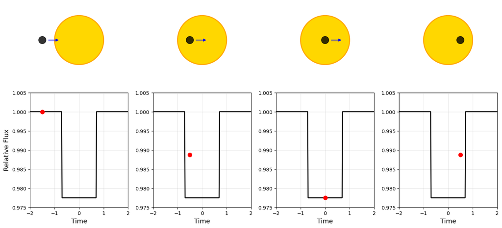

```python
import matplotlib.patches as patches

# Create figure: 2 rows × 4 columns (top = geometry, bottom = light curve)
fig, axes = plt.subplots(2, 4, figsize=(14, 7))

# Define four key transit phases with planet positions
positions = [
    (-1.5, 0, "Before transit"),
    (-0.5, 0, "Ingress"),
    (0, 0, "Mid-transit"),
    (0.5, 0, "Egress"),
]

# Set stellar and planetary radii for visualization
R_star = 1.0
R_planet = 0.15  # 15% of star's radius (exaggerated for visibility)

# Create time array and light curve
times = np.linspace(-2, 2, 200)
flux = np.ones_like(times)

# Simple box transit (flat-bottomed)
transit_start = -0.7
transit_end = 0.7
in_transit = (times > transit_start) & (times < transit_end)
flux[in_transit] = 1 - R_planet**2  # Depth = (Rp/Rs)²

# Loop through each transit phase and create the visualization
for i, (x_planet, y_planet, label) in enumerate(positions):
    ax_top = axes[0, i]
    ax_bottom = axes[1, i]

    # Top panel: Draw star and planet at this phase
    star = patches.Circle((0, 0), R_star, color='gold', ec='orange', lw=2)
    ax_top.add_patch(star)

    planet = patches.Circle((x_planet, y_planet), R_planet, color='black', alpha=0.8)
    ax_top.add_patch(planet)

    ax_top.set_xlim(-2, 2)
    ax_top.set_ylim(-1.5, 1.5)
    ax_top.set_aspect('equal')
    ax_top.axis('off')

    # Add arrow showing planet motion direction
    if i < 3:
        ax_top.arrow(x_planet + R_planet + 0.1, 0, 0.3, 0,
                    head_width=0.1, head_length=0.1, fc='blue', ec='blue')

    # Bottom panel: Show light curve with current phase marked
    ax_bottom.plot(times, flux, 'k-', lw=2)

    # Determine current position on light curve for each phase
    if i == 0:  # Before transit
        current_time = -1.5
        current_flux = 1.0
    elif i == 1:  # Ingress (partial blocking)
        current_time = -0.5
        current_flux = 1 - 0.5 * R_planet**2
    elif i == 2:  # Mid-transit (maximum blocking)
        current_time = 0
        current_flux = 1 - R_planet**2
    else:  # Egress (partial blocking)
        current_time = 0.5
        current_flux = 1 - 0.5 * R_planet**2

    # Mark current position with red dot
    ax_bottom.plot(current_time, current_flux, 'ro', markersize=8)

    ax_bottom.set_xlim(-2, 2)
    ax_bottom.set_ylim(0.975, 1.005)
    ax_bottom.set_xlabel('Time', fontsize=13)
    if i == 0:
        ax_bottom.set_ylabel('Relative Flux', fontsize=13)
    ax_bottom.grid(True, alpha=0.3)

plt.tight_layout()
plt.show()
```

This visualization shows the key phases of a transit. Before transit, we receive 100% of the star's light. At mid-transit, the planet is fully on the stellar disk and blocks maximum light, creating a dip in the light curve.

### Transit Depth: Planet Size from Geometry

The fundamental physics of transits is beautifully simple. When a planet passes in front of a star, it blocks light proportional to its cross-sectional area. Since both the planet and star appear as circular disks from Earth, the fraction of blocked light is:

$$\text{Transit Depth} = \frac{\text{Area of planet}}{\text{Area of star}} = \frac{\pi R_p^2}{\pi R_\star^2} = \left(\frac{R_p}{R_\star}\right)^2$$

This quadratic relationship means even small planets produce measurable signals. Astronomers typically express transit depths in parts per million (ppm), where $1\text{ ppm} = 0.0001\% = 10^{-6}$. This unit is convenient because typical transit depths are very small.

Let's calculate transit depths for different planets using `astropy` constants:

```python
# Calculate transit depths
depth_earth = (R_earth / R_sun)**2
depth_jupiter = (R_jupiter / R_sun)**2

print("Transit Depths for Planets Transiting the Sun:")
print("-" * 50)
print(f"Earth:")
print(f"  Radius ratio: {R_earth/R_sun:.5f}")
print(f"  Transit depth: {depth_earth*1e6:.1f} ppm = {depth_earth*100:.5f}%")

print(f"\nJupiter:")
print(f"  Radius ratio: {R_jupiter/R_sun:.4f}")
print(f"  Transit depth: {depth_jupiter*1e6:.0f} ppm = {depth_jupiter*100:.2f}%")
```

```
Transit Depths for Planets Transiting the Sun:
--------------------------------------------------
Earth:
  Radius ratio: 0.00917 1 / m
  Transit depth: 84.1 1 / m2 ppm = 0.00841 1 / m2%

Jupiter:
  Radius ratio: 0.1028 1 / m
  Transit depth: 10560 1 / m2 ppm = 1.06 1 / m2%
```

Earth produces an 84 ppm transit depth, while Jupiter produces a much larger 10,000 ppm signal. These numbers reveal why space telescopes were essential for finding Earth-sized planets. Ground-based telescopes, limited to ~1000 ppm precision by atmospheric turbulence, can only detect giant planets.

The Kepler Space Telescope as discussed above was specifically designed to answer: How common are Earth-like planets? Kepler achieved ~20 ppm precision for bright stars—an astonishing level of sensitivity. To put this in perspective: if Kepler collects one million photons from a star, it can reliably detect if just 20 photons are missing. This is like counting a million grains of sand and noticing that 20 are absent.

This extraordinary precision made it possible to detect the 84 ppm Earth signal. Kepler revealed that small planets are extremely common: approximately 20-50% of Sun-like stars have Earth-sized planets in or near the habitable zone. Before Kepler, we knew of a few hundred exoplanets, mostly hot Jupiters. After Kepler, we know that Earth-like worlds are abundant throughout the galaxy—one of the most important discoveries in modern astronomy.

### Inclination and the Impact Parameter

In reality, not all planets transit their host stars—it depends on the orbital inclination $i$ (the angle between the orbital plane and our line of sight). An inclination of $i = 90°$ is perfectly edge-on, where the planet crosses through the center of the stellar disk. An inclination of $i = 0°$ would be face-on, where no transit occurs at all. Even for planets that do transit, if the inclination is slightly less than 90°, the planet's path crosses the stellar disk off-center rather than through the middle.

The orbital inclination determines where the planet's path crosses the stellar disk, quantified by the impact parameter $b$:

$$b = \frac{a \cos i}{R_\star}$$

where $a$ is the semi-major axis (the planet's orbital radius), $i$ is the orbital inclination, and $R_\star$ is the stellar radius.

To understand this formula: imagine looking at the orbit edge-on. The planet orbits at distance $a$ from the star's center. When the orbit is tilted by angle $i$ from edge-on, the planet's path across our line of sight is shifted by $a \cos i$ from the star's center. Dividing by $R_\star$ expresses this in units of stellar radii.

The impact parameter $b$ tells us how close the planet's path passes to the stellar center (measured in stellar radii):

- $b = 0$ for a central transit (perfectly edge-on, $i = 90°$, so $\cos i = 0$)
- $b \approx 1$ for a grazing transit that barely clips the stellar edge
- $b > 1$ means the planet's path misses the star entirely, so no transit occurs

Let's visualize how the impact parameter affects transit shape:

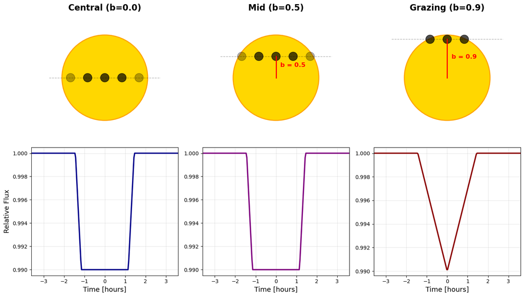

```python
fig, axes = plt.subplots(2, 3, figsize=(14, 8))

# Three impact parameter cases to compare
impact_params = [0.0, 0.5, 0.9]
labels = ["Central (b=0.0)", "Mid (b=0.5)", "Grazing (b=0.9)"]
colors = ['darkblue', 'purple', 'darkred']

# Star and planet sizes for visualization
R_star_plot = 1.0
R_planet_plot = 0.1
times_transit = np.linspace(-0.15, 0.15, 200)  # days

# Loop through each impact parameter case and create visualizations
for idx, (b, label, color) in enumerate(zip(impact_params, labels, colors)):
    ax_geom = axes[0, idx]
    ax_lc = axes[1, idx]

    # Top panel: Show transit geometry with planet path
    circle = plt.Circle((0, 0), R_star_plot, color='gold', ec='orange', lw=2)
    ax_geom.add_patch(circle)

    # Draw planet's path (horizontal line at height b)
    path_y = b * R_star_plot
    path_x = np.linspace(-1.3, 1.3, 50)
    ax_geom.plot(path_x, np.full_like(path_x, path_y), 'k--', lw=1, alpha=0.3)

    # Show planet at multiple positions along its path
    n_positions = 7
    for i, frac in enumerate(np.linspace(-1, 1, n_positions)):
        x_pos = frac * 1.2 * R_star_plot
        y_pos = path_y
        dist_from_center = np.sqrt(x_pos**2 + y_pos**2)
        if dist_from_center < R_star_plot + R_planet_plot:
            alpha_val = 0.7 if abs(frac) < 0.5 else 0.3
            planet_circle = plt.Circle((x_pos, y_pos), R_planet_plot,
                                      color='black', alpha=alpha_val)
            ax_geom.add_patch(planet_circle)

    ax_geom.set_xlim(-1.5, 1.5)
    ax_geom.set_ylim(-1.5, 1.5)
    ax_geom.set_aspect('equal')
    ax_geom.set_title(label, fontsize=16, fontweight='bold')
    ax_geom.axis('off')

    # Annotate impact parameter if non-zero
    if b > 0:
        ax_geom.plot([0, 0], [0, path_y], 'r-', lw=2)
        ax_geom.text(0.1, path_y/2, f'b = {b}', fontsize=12, color='red',
                    fontweight='bold')

    # Bottom panel: Generate trapezoidal transit light curve
    flux = np.ones_like(times_transit)

    # Transit parameters depend on impact parameter
    T_total = 0.12  # Total transit duration in days

    # Use SAME formula as trapezoidal_transit_model fitting function
    # From geometry: t_ingress / T_total = R_p / R_star
    T_ingress = T_total * R_planet_plot / R_star_plot  # Ingress/egress duration

    # Depth decreases with impact parameter (grazing transits are shallower)
    max_depth = R_planet_plot**2
    if b < 1 - R_planet_plot:
        # Planet fully enters disk
        depth = max_depth
        has_flat_bottom = True
    else:
        # Grazing: planet doesn't fully enter, reduced depth
        depth = max_depth * (1 - b)**2 / R_planet_plot**2
        has_flat_bottom = False

    for j, t in enumerate(times_transit):
        abs_t = np.abs(t)

        if abs_t < T_total / 2:
            if has_flat_bottom:
                # Trapezoidal shape
                if abs_t <= (T_total / 2 - T_ingress):
                    # Flat bottom (center of transit)
                    flux[j] = 1 - depth
                else:
                    # Ingress or egress (linear slopes near edges)
                    # Distance from edge of transit
                    dist_from_edge = T_total / 2 - abs_t
                    fraction_depth = dist_from_edge / T_ingress
                    flux[j] = 1 - depth * max(0, min(1, fraction_depth))
            else:
                # V-shaped (grazing): maximum depth at center, linear slopes to edge
                fraction_depth = 1 - abs_t / (T_total / 2)
                flux[j] = 1 - depth * max(0, fraction_depth)

    ax_lc.plot(times_transit * 24, flux, color=color, lw=2.5)
    ax_lc.set_xlabel('Time [hours]', fontsize=13)
    if idx == 0:
        ax_lc.set_ylabel('Relative Flux', fontsize=13)
    ax_lc.grid(True, alpha=0.3)
    ax_lc.set_xlim(-3.6, 3.6)

plt.tight_layout()
plt.show()
```

These light curves use the trapezoidal approximation with linear ingress/egress slopes—the model we'll use for fitting.

### The Trapezoidal Transit Model

The transit schematic we showed earlier depicted an instantaneous brightness drop. In reality, the planet has finite size $R_p$, so it takes time to fully cross the stellar limb—creating the characteristic trapezoidal light curve shape. We need a mathematical model that captures this geometry.

The trapezoidal model is a practical analytical approximation with four distinct phases: a flat baseline before and after the transit (no starlight blocked), a linear ingress as the planet moves onto the stellar disk, a flat bottom when the planet is fully on the disk, and a linear egress as the planet exits.

#### Ingress and Egress Duration

During the ingress phase, the planet moves a distance $2R_p$ as it transitions from first contact (planet's leading edge touches the stellar limb) to fully entering the disk. At orbital velocity $v$, the ingress duration is:

$$t_{\rm ingress} = \frac{2R_p}{v}$$

Using the relation $v = 2\pi a / P$ for circular orbits, we can rewrite this as:

$$t_{\rm ingress} = \frac{2R_p}{2\pi a/P} = \frac{R_p P}{\pi a}$$

This reveals a key insight: measuring the ingress and egress slopes directly reveals the planet radius! The steeper the slopes, the smaller the planet.

#### Total Transit Duration and Impact Parameter

Most transits are not perfectly central. The impact parameter $b$ (defined earlier as $b = a\cos i / R_\star$) determines how close the planet's path passes to the stellar center. This affects the chord length that the planet travels across the stellar disk. For a transit with impact parameter $b$, the chord length is $2R_\star\sqrt{1-b^2}$, giving a total duration of:

$$T_{\rm total} = \frac{2R_\star\sqrt{1-b^2}}{v}$$

When $b = 0$ (central transit), we get $T_{\rm total} = 2R_\star/v$, the maximum possible duration. When $b \to 1$ (grazing transit), $T_{\rm total} \to 0$ as the planet barely clips the stellar edge.

#### Breaking the Degeneracy

We have three observables (transit depth, total duration, and ingress/egress duration) and three unknowns ($R_p/R_\star$, $b$, and $v$). However, this assumes we know $R_\star$—the stellar radius. In practice, $R_\star$ is often challenging to determine precisely, though it can be modeled if we understand the star's properties through spectroscopy and stellar evolution models. Assuming $R_\star$ is known, the key is to take the ratio of the two durations:

$$\frac{t_{\rm ingress}}{T_{\rm total}} = \frac{2R_p/v}{2R_\star\sqrt{1-b^2}/v} = \frac{R_p}{R_\star\sqrt{1-b^2}}$$

Notice that the orbital velocity $v$ cancels out! Now we have two independent ratios: the transit depth gives us $R_p/R_\star$ directly (from $\sqrt{\delta}$), while the duration ratio gives us $R_p/(R_\star\sqrt{1-b^2})$. Dividing the duration ratio by the depth ratio, we can solve for $b$:

$$\frac{R_p/(R_\star\sqrt{1-b^2})}{R_p/R_\star} = \frac{1}{\sqrt{1-b^2}}$$

Once we know $b$, we can determine $v$ from the total duration with $R_\star$ known. The result is remarkable: from a single transit light curve, we can simultaneously extract the planet-to-star radius ratio $R_p/R_\star$, the impact parameter $b$, the total duration $T_{\rm total}$, and the orbital velocity $v$. These four parameters completely characterize the transit geometry if we also know $R_\star$.

#### Why Use the Trapezoidal Approximation?

The trapezoidal model is an approximation, not exact physics. In reality, when a circular planet crosses a circular star, the overlapping area follows complex geometry (involving arccos functions), creating slightly curved ingress/egress slopes rather than perfectly linear ones.

Advantages of the trapezoidal model: The trapezoidal approximation offers several key benefits. It's fast, relying on simple analytical formulas without complex geometry calculations. It provides a good approximation that works very well for central and moderately offset transits ($b \lesssim 0.5$), which comprise most detectable transits. The model is interpretable, with clear physical meaning for all parameters, and robust—getting you 90% of the way there for initial characterization.

When does it break down? For grazing transits ($b \gtrsim 0.8$) or very high precision work (sub-percent uncertainties), the curved geometry matters. Professional research uses exact circular models (packages like `batman`, `pytransit`, or `exoplanet`), but for learning transit fitting principles, the trapezoidal model is ideal.

## Fitting a Single Transit: Learning the Basics

Now that we understand transit physics and models, let's apply curve fitting to transit data. We'll start by analyzing a single, isolated transit—imagine you've observed one clear transit event. This approach lets us focus on the curve fitting techniques from Lecture 18 without worrying about complications like finding periods or combining multiple transits.

Our strategy: We'll generate synthetic observations using the trapezoidal model (adding realistic noise), then fit them with the same model using `scipy.optimize.curve_fit`. This demonstrates how to extract physical parameters (planet radius ratio, transit duration, mid-transit time) from noisy photometric data—the same approach used in real exoplanet research.

This is pedagogically valuable: we can extract meaningful parameters from just ONE transit, without ever knowing the orbital period. Later, we'll learn how to handle real observations with multiple transits and period finding.

### Generating Simulated Single Transit Data

Let's create synthetic data for a realistic exoplanet transit using the trapezoidal model. We'll simulate a hot Jupiter—a gas giant orbiting very close to its host star. These were among the first exoplanets detected by transit surveys, and their large size produces strong, easily detectable signals.

The key metric for detectability is the signal-to-noise ratio (SNR): the ratio of the transit depth (our signal) to the photometric noise level. An SNR of 1 means the signal equals the noise—barely detectable. SNR > 5 typically allows confident detection. With a hot Jupiter's large radius ratio (10%) transiting a Sun-like star, we get a transit depth of 10,000 ppm. We will assume a conservative 300 ppm in our study below (note that Kepler can reach 20 ppm), this gives SNR ≈ 33—excellent detectability that allows precise parameter recovery even from a single transit.

#### Input Physical Parameters

To generate our synthetic transit, we start with the fundamental physical parameters of the system, then calculate the observable transit characteristics from these. This mirrors how transit observations work in reverse: we observe the light curve and fit it to recover the physical parameters.

We specify three key physical parameters:

1. **Planet-to-star radius ratio ($R_p/R_\star$)**: The relative size of the planet. We'll use 0.10 (10%), representing a hot Jupiter transiting a Sun-like star.
2. **Impact parameter ($b$)**: Describes how centrally the planet crosses the stellar disk (0 = perfectly central, approaching 1 = grazing). We'll use $b = 0.3$, a moderately off-center transit.
3. **Orbital velocity ($v$)**: How fast the planet moves in its orbit. We'll use 150 km/s, typical for a hot Jupiter on a very close (~3-day) orbit.

We also need the stellar radius, which we assume is Sun-like ($R_\star = R_\odot$).

From these physical parameters, we can calculate the observable transit characteristics:

- **Transit depth**: $\delta = (R_p/R_\star)^2$
- **Transit duration**: From the geometry, the planet crosses a chord of length $2R_\star\sqrt{1-b^2}$ at velocity $v$, giving:

$$T_{\rm total} = \frac{2R_\star\sqrt{1-b^2}}{v}$$

- **Ingress duration**: The planet's diameter is $2R_p = 2(R_p/R_\star)R_\star$. Crossing at velocity $v$:

$$T_{\rm ingress} = \frac{2R_p}{v}$$

Let's set up the simulation:

```python
# Physical parameters of the system
rp_rs = 0.10  # Planet-to-star radius ratio (10% = Hot Jupiter)
impact_param = 0.3  # Impact parameter (0 = central, <1 = transiting)
orbital_velocity = 150.0 * u.km / u.s  # Orbital velocity of planet (faster for closer orbit)

# Stellar properties (assume Sun-like star)
R_star_sim = const.R_sun.to(u.km)  # Solar radius

# Calculate observable transit characteristics from physical parameters
depth = rp_rs**2  # Transit depth from geometry

# Transit duration from geometry: T = 2*R_star*sqrt(1-b^2) / v
chord_length = 2 * R_star_sim * np.sqrt(1 - impact_param**2)  # km
transit_duration = (chord_length / orbital_velocity).to(u.day)  # Convert to days

# Ingress/egress duration from geometry: t_ingress = 2*Rp / v
planet_diameter = 2 * rp_rs * R_star_sim  # Diameter of planet in km
ingress_duration = (planet_diameter / orbital_velocity).to(u.day)  # Convert to days

# Observational noise
noise_ppm = 300  # Realistic space-based photometry noise

# Transit center time for simulation (t0 = 0 for convenience)
t0_sim = 0.0

print(f"Physical parameters:")
print(f"  Rp/Rs = {rp_rs:.3f}")
print(f"  Impact parameter b = {impact_param:.2f}")
print(f"  Orbital velocity v = {orbital_velocity.value:.1f} km/s")
print(f"  Stellar radius R* = {R_star_sim.value:.0f} km")
print(f"\nDerived observable characteristics:")
print(f"  Chord length = {chord_length.value:.0f} km (2R* × √(1-b²))")
print(f"  Transit duration = {transit_duration.value:.4f} days = {transit_duration.to(u.hour).value:.2f} hours")
print(f"  Ingress duration = {ingress_duration.value:.6f} days = {ingress_duration.to(u.minute).value:.1f} minutes")
print(f"  Transit depth = {depth:.6f} = {depth*1e6:.0f} ppm")
print(f"\nObservational setup:")
print(f"  Noise level = {noise_ppm} ppm")
print(f"  Signal-to-Noise Ratio (SNR): {depth*1e6/noise_ppm:.1f}")
```

```
Physical parameters:
  Rp/Rs = 0.100
  Impact parameter b = 0.30
  Orbital velocity v = 150.0 km/s
  Stellar radius R* = 695700 km

Derived observable characteristics:
  Chord length = 1327311 km (2R* × √(1-b²))
  Transit duration = 0.1024 days = 2.46 hours
  Ingress duration = 0.010736 days = 15.5 minutes
  Transit depth = 0.010000 = 10000 ppm

Observational setup:
  Noise level = 300 ppm
  Signal-to-Noise Ratio (SNR): 33.3
```

Create a time array covering the transit region, centered at t=0 (mid-transit):

```python
# Time array: ±3 hours around mid-transit
n_points = 500
times_single = np.linspace(-0.125, 0.125, n_points)  # days
```

Now we'll define the trapezoidal transit model function that we'll use for both generating data and fitting. This is the same model shown in the visualization above—it captures the essential physics with linear ingress/egress slopes:

```python
def trapezoidal_transit_model(times, t0, depth, duration, ingress_duration):
    """
    Trapezoidal transit model using observable parameters.

    Models transit light curve with linear ingress/egress, automatically handling
    both flat-bottomed and grazing (V-shaped) transits based on ingress/duration ratio.

    Parameters (all directly observable from light curve):
    - t0: time of transit center [days] (nuisance parameter - observation reference)
    - depth: transit depth (fractional flux decrease, 0-1)
    - duration: total transit duration [days] (Contact I to IV)
    - ingress_duration: duration of ingress or egress [days]

    Returns:
    - model_flux: predicted normalized flux values

    Note:
    - If 2*ingress_duration < duration: flat-bottomed transit (trapezoid)
    - If 2*ingress_duration >= duration: grazing transit (triangle/V-shape)
    """
    model_flux = np.ones_like(times)

    # Calculate distance from transit center
    dt = times - t0
    abs_dt = np.abs(dt)

    # Determine transit shape from observables
    # Flat bottom exists if ingress+egress don't fill entire duration
    flat_duration = duration - 2 * ingress_duration
    has_flat_bottom = (flat_duration > 0)

    if has_flat_bottom:
        # STANDARD TRAPEZOIDAL: ingress + flat bottom + egress

        # Ingress/egress: linear transitions at edges
        ingress_mask = (abs_dt < duration/2) & (abs_dt >= duration/2 - ingress_duration)
        if np.any(ingress_mask):
            # Fraction of planet on disk increases linearly from 0 to 1
            ingress_frac = (duration/2 - abs_dt[ingress_mask]) / ingress_duration
            model_flux[ingress_mask] = 1 - depth * ingress_frac

        # Flat bottom: full depth
        full_mask = abs_dt < (duration/2 - ingress_duration)
        model_flux[full_mask] = 1 - depth

    else:
        # GRAZING TRANSIT: V-shaped (ingress blends directly into egress)
        # Depth varies linearly from maximum at center to zero at edges

        transit_mask = abs_dt < duration/2
        if np.any(transit_mask):
            # Fraction from center (0 at center, 1 at edge)
            frac_from_center = abs_dt[transit_mask] / (duration/2)
            # Depth decreases linearly from center to edge
            model_flux[transit_mask] = 1 - depth * (1 - frac_from_center)

    return model_flux
```

Generate the true transit signal using the trapezoidal model:

```python
# True transit signal (no noise) - using the trapezoidal model with observable parameters
flux_true = trapezoidal_transit_model(times_single, t0_sim, depth, transit_duration.value, ingress_duration.value)
```

Add realistic observational noise:

```python
# Add Gaussian noise
noise_per_point = noise_ppm * 1e-6
noise = np.random.normal(0, noise_per_point, n_points)
flux_observed = flux_true + noise
flux_err = np.full(n_points, noise_per_point)

print(f"\nSignal-to-noise ratio: {depth/noise_per_point:.1f}")
```

```
Signal-to-noise ratio: 33.3
```

Visualize the simulated observation:

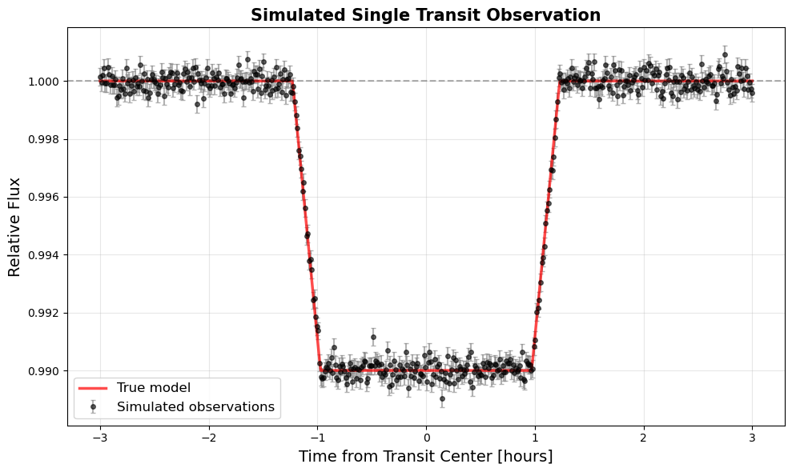

```python
# Plot the single transit observation
plt.figure(figsize=(10, 6))
plt.errorbar(times_single * 24, flux_observed, yerr=flux_err,
             fmt='o', markersize=4, alpha=0.6, color='black',
             ecolor='gray', capsize=2, label='Simulated observations')
plt.plot(times_single * 24, flux_true, 'r-', linewidth=2.5,
         alpha=0.7, label='True model')
plt.xlabel('Time from Transit Center [hours]', fontsize=14)
plt.ylabel('Relative Flux', fontsize=14)
plt.title('Simulated Single Transit Observation', fontsize=15, fontweight='bold')
plt.legend(fontsize=12)
plt.grid(True, alpha=0.3)
plt.axhline(1.0, color='k', linestyle='--', alpha=0.3)
plt.tight_layout()
plt.show()
```

This plot shows one complete transit centered at time = 0, generated using the trapezoidal model. The linear ingress and egress slopes arise from the finite planet size gradually covering and uncovering the stellar disk.

### Fitting the Transit Model

Now let's fit the trapezoidal model to our simulated data using `scipy.optimize.curve_fit` from Lecture 18.

With our hot Jupiter's excellent SNR ~ 33, the transit signal is clearly visible above the noise. However, as discussed in Lecture 18, optimization algorithms can still get trapped in local minima, especially when fitting complex models with multiple parameters. A single initial guess might converge to a suboptimal solution.

The solution: Multiple random starts. We'll try many different initial parameter guesses (drawn randomly from reasonable ranges), run curve_fit on each one, and select the result with the lowest $\chi^2$. This robust approach ensures we find the global best fit, exploring the parameter space thoroughly to avoid local minima.

First, define parameter bounds to constrain the search space:

```python
# Set bounds to guide the optimizer and prevent unphysical solutions
# Parameters: [t0, depth, duration, ingress_duration]
# For ingress: realistic range is T_total * (Rp/Rs) / sqrt(1-b²)
#   For Rp/Rs up to 0.15 and b<0.9: ingress < 0.015 days
bounds = (
    [-0.05, 0.0001, 0.05, 0.001],      # Lower bounds
    [ 0.05, 0.05, 0.25, 0.015]         # Upper bounds: tighter ingress bound for stability
)
```

Multiple random starts help ensure we find the global optimum:

```python
# Multiple Random Starts Strategy
# Try many different initial guesses and pick the best result
n_tries = 30  # Number of random starting points to try
results = []

print(f"Trying {n_tries} random initial guesses...")

for i in range(n_tries):
    # Generate random initial guesses within reasonable ranges
    # Parameters: [t0, depth, duration, ingress_duration]
    random_t0 = np.random.uniform(-0.04, 0.04)  # Mid-transit time around 0
    random_depth = np.random.uniform(0.0005, 0.01)  # Transit depth (0.05% to 1%)
    random_duration = np.random.uniform(0.08, 0.22)  # Total duration in days
    random_ingress = np.random.uniform(0.002, 0.012)  # Ingress duration in days

    p0_random = [random_t0, random_depth, random_duration, random_ingress]

    try:
        # Try fitting with this random initial guess
        popt_try, pcov_try = optimize.curve_fit(
            trapezoidal_transit_model,
            times_single,
            flux_observed,
            p0=p0_random,
            sigma=flux_err,
            absolute_sigma=True,
            bounds=bounds,
            maxfev=10000  # Allow more iterations for difficult fits
        )

        # Calculate chi-squared for this fit
        model_try = trapezoidal_transit_model(times_single, *popt_try)
        chi_sq = np.sum(((flux_observed - model_try) / flux_err)**2)

        results.append({
            'chi_squared': chi_sq,
            'fitted_params': popt_try,
            'covariance': pcov_try,
            'success': True
        })

    except Exception as e:
        results.append({'success': False})

# Find the best result (lowest chi-squared)
successful_results = [r for r in results if r.get('success', False)]

if len(successful_results) > 0:
    best_result = min(successful_results, key=lambda x: x['chi_squared'])
    chi_sq_values = [r['chi_squared'] for r in successful_results]

    # Extract best fit parameters (observables)
    popt = best_result['fitted_params']
    pcov = best_result['covariance']
    t0_fit, depth_fit, duration_fit, ingress_fit = popt
    errors = np.sqrt(np.diag(pcov))

    print(f"\n{len(successful_results)}/{n_tries} fits succeeded")
    print(f"χ² range: [{min(chi_sq_values):.1f}, {max(chi_sq_values):.1f}]")
    print(f"Best χ² = {best_result['chi_squared']:.1f}")

    print("\nFitted Observable Parameters (Best of 30 attempts):")
    print("="*60)
    print(f"t0           = {t0_fit:10.6f} ± {errors[0]:.6f} days")
    print(f"Depth        = {depth_fit:10.6f} ± {errors[1]:.6f} ({depth_fit*1e6:.0f} ± {errors[1]*1e6:.0f} ppm)")
    print(f"Duration     = {duration_fit:10.6f} ± {errors[2]:.6f} days ({duration_fit*24:.2f} ± {errors[2]*24:.2f} hours)")
    print(f"Ingress dur  = {ingress_fit:10.6f} ± {errors[3]:.6f} days ({ingress_fit*24*60:.1f} ± {errors[3]*24*60:.1f} min)")
else:
    print(f"\nWARNING: No fits succeeded out of {n_tries} attempts!")
    print("There may be an issue with the bounds or initial guesses.")
```

```
Trying 30 random initial guesses...

30/30 fits succeeded
χ² range: [476.1, 476.1]
Best χ² = 476.1

Fitted Observable Parameters (Best of 30 attempts):
============================================================
t0           =   0.000088 ± 0.000050 days
Depth        =   0.009975 ± 0.000024 (9975 ± 24 ppm)
Duration     =   0.102446 ± 0.000203 days (2.46 ± 0.00 hours)
Ingress dur  =   0.010759 ± 0.000179 days (15.5 ± 0.3 min)
```

Calculate fit quality:

```python
# Generate model with fitted parameters
model_fit = trapezoidal_transit_model(times_single, *popt)

# Calculate chi-squared
chi2 = np.sum(((flux_observed - model_fit) / flux_err)**2)
dof = len(flux_observed) - len(popt)
chi2_red = chi2 / dof

print(f"\nFit quality:")
print(f"  χ² = {chi2:.1f}")
print(f"  DOF = {dof}")
print(f"  Reduced χ² = {chi2_red:.3f}")
```

```
Fit quality:
  χ² = 476.1
  DOF = 496
  Reduced χ² = 0.960
```

The reduced χ² should be close to 1.0 for a good fit—values much larger suggest the model doesn't fit the data or we've underestimated uncertainties, while values much smaller suggest we've overestimated uncertainties.

Visualize the fit quality:

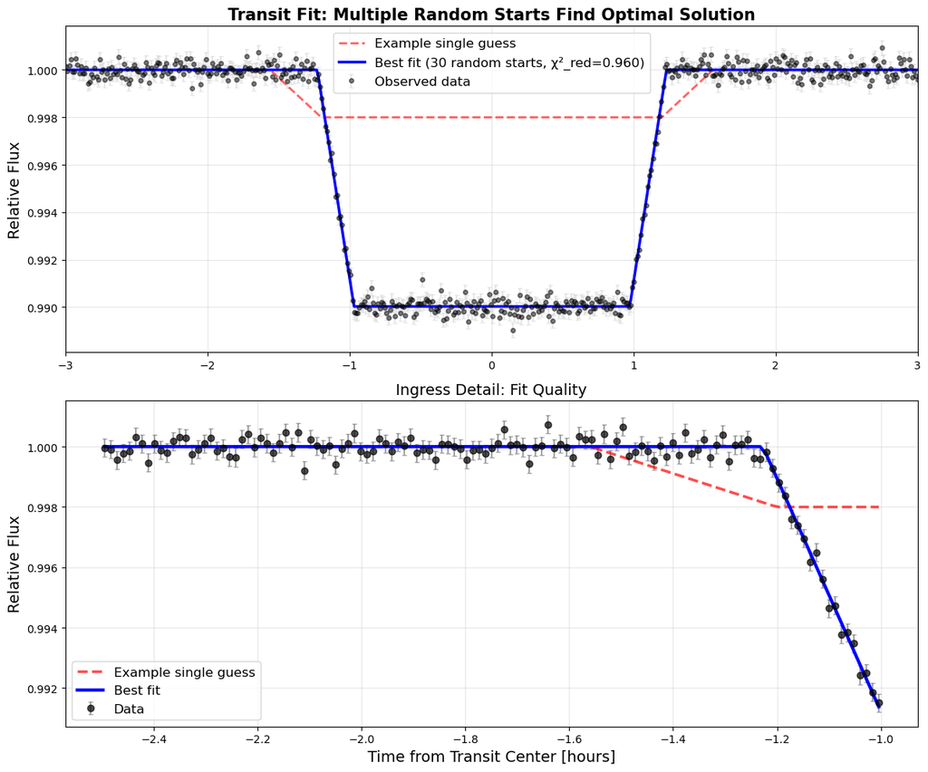

```python
# For visualization, show one example initial guess (not used in actual fitting)
# Parameters: [t0, depth, duration, ingress_duration]
p0_example = [0.0, 0.002, 0.13, 0.015]  # Example guess: slightly wrong depth and durations
model_example = trapezoidal_transit_model(times_single, *p0_example)

# Plot: data, example initial guess, and best fit from multiple random starts
fig, (ax1, ax2) = plt.subplots(2, 1, figsize=(12, 10))

# Top panel: Full transit
ax1.errorbar(times_single * 24, flux_observed, yerr=flux_err,
             fmt='o', markersize=4, alpha=0.5, color='black',
             ecolor='lightgray', capsize=2, label='Observed data')
ax1.plot(times_single * 24, model_example, 'r--', linewidth=2,
         alpha=0.6, label='Example single guess')
ax1.plot(times_single * 24, model_fit, 'b-', linewidth=2.5,
         label=f'Best fit (30 random starts, χ²_red={chi2_red:.3f})')
ax1.set_ylabel('Relative Flux', fontsize=14)
ax1.set_title('Transit Fit: Multiple Random Starts Find Optimal Solution', fontsize=15, fontweight='bold')
ax1.legend(fontsize=12)
ax1.grid(True, alpha=0.3)
ax1.set_xlim(-3, 3)

# Bottom panel: Zoom on ingress
ingress_mask = (times_single * 24 > -2.5) & (times_single * 24 < -1)
ax2.errorbar(times_single[ingress_mask] * 24, flux_observed[ingress_mask],
             yerr=flux_err[ingress_mask],
             fmt='o', markersize=6, alpha=0.7, color='black',
             ecolor='gray', capsize=2, label='Data')
ax2.plot(times_single[ingress_mask] * 24, model_example[ingress_mask],
         'r--', linewidth=2.5, alpha=0.7, label='Example single guess')
ax2.plot(times_single[ingress_mask] * 24, model_fit[ingress_mask],
         'b-', linewidth=3, label='Best fit')
ax2.set_xlabel('Time from Transit Center [hours]', fontsize=14)
ax2.set_ylabel('Relative Flux', fontsize=14)
ax2.set_title('Ingress Detail: Fit Quality', fontsize=14)
ax2.legend(fontsize=12)
ax2.grid(True, alpha=0.3)

plt.tight_layout()
plt.show()
```

Our fitting model had four observable parameters. Note that only three of these reflect fundamental physical properties of the planetary system—the fourth ($t_0$) is a timing reference that depends on when we started our observations:

1. **Transit center time** ($t_0$): The exact moment of mid-transit. This is not a physical property of the system, but a nuisance parameter we must fit because we don't know in advance exactly when the transit occurs in our time series. In our simulation we set $t_0 = 0$ for convenience, but in real observations the transit could occur at any time within our observing window.
2. **Transit depth** ($\delta$): The fractional decrease in brightness, directly observable from the light curve. Related to the planet-to-star radius ratio via $\delta = (R_p/R_\star)^2$.
3. **Total transit duration** ($\tau$): The time from first to fourth contact. Observable directly from the light curve and determined by the planet's orbital velocity, stellar radius, and impact parameter.
4. **Ingress/egress duration** ($\tau_{\rm ingress}$): The time for the planet to fully enter or exit the stellar disk. Observable from the light curve slope and related to the planet size and velocity.

From these four fitted observables, we can recover the three underlying physical parameters:

- Planet-to-star radius ratio: from $R_p/R_\star = \sqrt{\delta}$ (depth)
- Impact parameter: from the ratio $\tau_{\rm ingress}/\tau$ combined with $R_p/R_\star$
- Orbital velocity: from $v = 2R_\star\sqrt{1-b^2}/\tau$ (combining duration and recovered impact parameter)

Given stellar radius, we can then derive absolute physical properties like planet radius (km), orbital velocity (km/s), and eventually (with period) semi-major axis and equilibrium temperature.

Let's compare our recovered physical parameters to the true values we used to generate the data:

```python
print("\nObservable Parameter Recovery:")
print("="*70)
print(f"{'Observable':<20} {'True':<12} {'Fitted':<15} {'Error (sigma)':<15}")
print("-"*70)

# True values of fitted observable parameters
true_vals = [t0_sim, depth, transit_duration.value, ingress_duration.value]
param_names = ['t0 [days]', 'Depth', 'Duration [days]', 'Ingress [days]']

for i, (name, true, fitted, err) in enumerate(zip(param_names, true_vals, popt, errors)):
    sigma_off = abs(true - fitted) / err if err > 0 else 0
    print(f"{name:<20} {true:<12.6f} {fitted:<15.6f} {sigma_off:<15.2f}")

# Now convert fitted observables back to physical parameters
print("\n" + "="*70)
print("Converting Fitted Observables → Physical Parameters:")
print("="*70)

# 1. Planet-to-star radius ratio from depth
rp_rs_recovered = np.sqrt(depth_fit)

# 2. Impact parameter and velocity from duration and ingress
# From geometry:
#   T_total = 2*R_star*sqrt(1-b^2) / v
#   T_ingress = 2*Rp / v = 2*(Rp/Rs)*R_star / v
# Taking ratio: T_ingress/T_total = (Rp/Rs) / sqrt(1-b^2)
# Solving: sqrt(1-b^2) = (Rp/Rs) * T_total / T_ingress

sqrt_1_minus_b2 = rp_rs_recovered * duration_fit / ingress_fit
# Clamp to valid range to avoid numerical issues
sqrt_1_minus_b2 = min(sqrt_1_minus_b2, 0.9999)  # b must be < 1
b_recovered = np.sqrt(1 - sqrt_1_minus_b2**2)

# 3. Orbital velocity from total duration and geometry
chord_recovered = 2 * R_star_sim * sqrt_1_minus_b2
duration_recovered = duration_fit * u.day
v_recovered = (chord_recovered / duration_recovered).to(u.km / u.s)

print(f"\n1. Planet-to-star radius ratio:")
print(f"   Rp/Rs = sqrt(depth) = sqrt({depth_fit:.6f}) = {rp_rs_recovered:.4f}")
print(f"   True value: {rp_rs:.4f}")
print(f"   Recovery error: {abs(rp_rs_recovered - rp_rs)/rp_rs * 100:.2f}%")

print(f"\n2. Impact parameter:")
print(f"   From T_ingress/T_total ratio: {ingress_fit/duration_fit:.4f}")
print(f"   sqrt(1-b²) = {sqrt_1_minus_b2:.4f}")
print(f"   b = {b_recovered:.3f}")
print(f"   True value: {impact_param:.3f}")
print(f"   Recovery error: {abs(b_recovered - impact_param):.3f}")

print(f"\n3. Orbital velocity:")
print(f"   v = 2*R*×sqrt(1-b²) / T_total")
print(f"   v = {v_recovered.value:.2f} km/s")
print(f"   True value: {orbital_velocity.value:.2f} km/s")
print(f"   Recovery error: {abs(v_recovered - orbital_velocity).value:.2f} km/s ({abs(v_recovered - orbital_velocity).value/orbital_velocity.value * 100:.2f}%)")

# 4. Planet radius in physical units (assuming Sun-like star)
print(f"\n4. Planet physical radius:")
R_star = const.R_sun.to(u.km)
R_planet = rp_rs_recovered * R_star
R_planet_earth = (R_planet / const.R_earth.to(u.km)).value
R_planet_jupiter = (R_planet / const.R_jup.to(u.km)).value
print(f"   Assuming R* = R☉ = {R_star.value:.0f} km")
print(f"   R_planet = {R_planet.value:.0f} km")
print(f"            = {R_planet_earth:.2f} R_Earth")
print(f"            = {R_planet_jupiter:.2f} R_Jupiter")
print(f"   (Hot Jupiter)")
```

```
Observable Parameter Recovery:
======================================================================
Observable           True         Fitted          Error (sigma)
----------------------------------------------------------------------
t0 [days]            0.000000     0.000088        1.76
Depth                0.010000     0.009975        1.07
Duration [days]      0.102416     0.102446        0.15
Ingress [days]       0.010736     0.010759        0.13

======================================================================
Converting Fitted Observables → Physical Parameters:
======================================================================

1. Planet-to-star radius ratio:
   Rp/Rs = sqrt(depth) = sqrt(0.009975) = 0.0999
   True value: 0.1000
   Recovery error: 0.13%

2. Impact parameter:
   From T_ingress/T_total ratio: 0.1050
   sqrt(1-b²) = 0.9510
   b = 0.309
   True value: 0.300
   Recovery error: 0.009

3. Orbital velocity:
   v = 2*R*×sqrt(1-b²) / T_total
   v = 149.50 km/s
   True value: 150.00 km/s
   Recovery error: 0.50 km/s (0.34%)

4. Planet physical radius:
   Assuming R* = R☉ = 695700 km
   R_planet = 69482 km
            = 10.89 R_Earth
            = 0.97 R_Jupiter
   (Hot Jupiter)
```

These results show excellent agreement between the recovered and true values, validating our approach of fitting observable parameters and then recovering the physical properties. The hot Jupiter has a radius of about 10 Earth radii (approximately 1 Jupiter radius), as expected for a gas giant. The orbital velocity of ~150 km/s is about 5 times faster than Earth's 30 km/s, consistent with a very close, short-period orbit typical of hot Jupiters.

## What We Cannot Determine from a Single Transit

We've successfully extracted meaningful physical parameters from our single transit observation. From the fitted planet-to-star radius ratio, we determined the planet's physical radius (approximately 10 Earth radii, Jupiter-sized). From the transit duration, we calculated the orbital velocity. This is already remarkably powerful—we've characterized a planet potentially thousands of light-years away from observing a dimming event!

However, several crucial parameters remain completely inaccessible from a single transit alone. These missing parameters all depend on knowing the orbital period—how frequently the transits repeat.

### The Missing Orbital Distance

The most fundamental missing parameter is the semi-major axis $a$ (orbital distance)—how far the planet orbits from its star. This tells us whether the planet is a scorching world close to its star or a frigid world far away. The orbital distance is essential for understanding the planetary system's architecture and the planet's physical conditions.

Once we know the period $P$, we can calculate the semi-major axis directly from kinematics. The planet travels one complete orbit (circumference $2\pi a$) in time $P$, so:

$$v = \frac{2\pi a}{P}$$

Rearranging to solve for the semi-major axis:

$$a = \frac{vP}{2\pi}$$

where $v$ is the orbital velocity we measured from the transit duration.

Without the period, we cannot calculate $a$, and we cannot proceed further in characterizing the planetary system.

### The Missing Temperature

With the orbital distance unknown, we also cannot calculate the planet's equilibrium temperature. The equilibrium temperature $T_{\rm eq}$ is the temperature a planet reaches when the energy it absorbs from its star equals the energy it radiates back to space. This depends critically on the distance from the star, which determines how much stellar flux the planet receives (stellar flux drops as $1/a^2$).

To derive the equilibrium temperature, we balance energy input and output. The planet absorbs stellar radiation over its cross-sectional area $\pi R_p^2$, but the stellar flux at distance $a$ is diluted compared to the stellar surface:

$$F_{\rm planet} = F_{\rm star} \left(\frac{R_\star}{a}\right)^2 = \sigma T_\star^4 \left(\frac{R_\star}{a}\right)^2$$

where $\sigma$ is the Stefan-Boltzmann constant. The planet absorbs energy at rate $(1-A) \times F_{\rm planet} \times \pi R_p^2$, where $A$ is the Bond albedo (fraction of light reflected). The planet radiates energy from its entire surface area $4\pi R_p^2$ at temperature $T_{\rm eq}$, emitting at rate $\sigma T_{\rm eq}^4 \times 4\pi R_p^2$.

Setting absorbed energy equal to radiated energy:

$$(1-A) \sigma T_\star^4 \left(\frac{R_\star}{a}\right)^2 \pi R_p^2 = \sigma T_{\rm eq}^4 \times 4\pi R_p^2$$

Canceling $\sigma$ and $\pi R_p^2$, then solving for $T_{\rm eq}$:

$$T_{\rm eq}^4 = (1-A) T_\star^4 \frac{R_\star^2}{4a^2}$$

Taking the fourth root gives the equilibrium temperature formula:

$$T_{\rm eq} = T_\star \sqrt{\frac{R_\star}{2a}} (1-A)^{1/4}$$

where $T_\star$ is the stellar temperature, $R_\star$ is the stellar radius, $a$ is the orbital distance, and $A$ is the Bond albedo (typically $A \approx 0.3$ for gas giants). Without knowing $a$, this calculation is impossible. The difference between a hot Jupiter at 0.05 AU and a cold Jupiter at 5 AU is the difference between molten rock (2000 K) and frozen methane (100 K)—but we cannot distinguish these scenarios from a single transit.

### Why Multiple Transits Are Essential

The period is the key that transforms transit photometry from measuring geometric parameters (planet size and orbital velocity) to complete physical characterization (orbital architecture and planetary conditions). But we cannot determine the period from a single transit—we need to observe multiple transits and search for the repeating pattern.

Beyond simply finding the period, multiple transits provide three additional critical benefits:

**1. Confirmation that the signal is real**: A single brightness dip could be instrumental noise, a stellar flare, or a cosmic ray hit—not a planet at all. Multiple periodic dips separated by exactly the same time interval provide strong evidence that we're observing a real orbiting body rather than random noise.

**2. The observational cadence challenge**: Our single-transit example above used dense time sampling—we placed 500 data points over 6 hours to beautifully resolve the transit shape. In reality, exoplanet surveys cannot continuously stare at one star with such high cadence. NASA's TESS mission, for example, typically operates with 10-minute cadence (one measurement every 10 minutes). For our 2.5-hour hot Jupiter transit, this gives ~15 data points per transit—sufficient to see the transit shape, but with limited ability to resolve fine details like the ingress and egress slopes.

With such moderate sampling, having multiple transits allows us to verify the periodic pattern and improve our measurements through phase folding.

**3. Phase folding to build up well-sampled transit profiles**: Once we know the period, we can "phase fold" all transits—mapping each transit onto a common time axis aligned at mid-transit, then stacking them together. This is essential even for moderately-sampled observations:

- **Building up sampling**: With 12 transits at ~15 points each, phase folding gives us ~180 points sampling the transit shape. Crucially, the points fall at slightly different phases (due to the incommensurate relationship between 10-minute cadence and the 2.55-day orbital period), so the folded transit is better sampled than any individual transit. This transforms moderately-sampled individual transits into an excellently-resolved combined profile, allowing more precise measurement of ingress/egress slopes and transit depth.
- **Bonus: SNR improvement**: As we discussed in Lecture 17, combining $N$ independent measurements improves signal-to-noise by $\sqrt{N}$. Phase folding 12 transits boosts SNR by a factor of $\sqrt{12} \approx 3.5$. For our hot Jupiter with SNR ~ 33 per transit, this pushes the combined SNR to over 100—enabling extremely precise parameter measurements with uncertainties well below 1%.

These combined benefits—period determination, signal confirmation, and especially building up well-sampled transits from sparse observations while improving SNR—make multi-transit observations absolutely essential for exoplanet characterization.

### Generating a Multi-Transit Light Curve

Let's generate synthetic observations covering 30 days, using the same parameters from our single transit. Now we'll add the orbital period:

```python
# Same physical parameters as before - reuse from single transit
# rp_rs, impact_param, orbital_velocity all remain the same
# transit_duration was calculated from these physical parameters

# Add orbital period for multi-transit scenario
period = 2.55  # days - short orbital period

print(f"Generating multi-transit light curve:")
print(f"  Period = {period:.2f} days")
print(f"  Physical parameters (same as single transit):")
print(f"    Rp/Rs = {rp_rs:.3f}")
print(f"    Impact parameter b = {impact_param:.2f}")
print(f"    Orbital velocity v = {orbital_velocity.value:.1f} km/s")
print(f"  Calculated transit duration = {transit_duration.value:.4f} days = {(transit_duration*24).value:.1f} hours")
print(f"  Observing span = 30 days")
print(f"  Expected number of transits = {30/period:.0f}")
```

```
Generating multi-transit light curve:
  Period = 2.55 days
  Physical parameters (same as single transit):
    Rp/Rs = 0.100
    Impact parameter b = 0.30
    Orbital velocity v = 150.0 km/s
  Calculated transit duration = 0.1024 days = 2.5 hours
  Observing span = 30 days
  Expected number of transits = 12
```

Define a multi-transit model function:

```python
def multi_transit_model(times, t0, period, depth, duration, ingress_duration):
    """
    Model for multiple transits with given period.
    Uses trapezoidal model with observable parameters for each transit.

    Parameters:
    - t0: time of first transit center
    - period: orbital period
    - depth, duration, ingress_duration: observable transit parameters

    Generates transit dips at t0, t0+P, t0+2P, ...
    """
    flux = np.ones_like(times)

    # For each time point, find closest transit center
    # and calculate that transit's contribution
    for t in times:
        # Phase within period
        phase = ((t - t0) % period) - period/2
        if abs(phase) < period/2:
            phase = phase if abs(phase) < abs(phase + period) else phase + period

        # Generate transit if within duration
        if abs(phase) < duration:
            flux_at_t = trapezoidal_transit_model(np.array([phase]), 0.0, depth, duration, ingress_duration)[0]
            idx = np.where(times == t)[0]
            if len(idx) > 0:
                flux[idx] = flux_at_t

    return flux
```

Now we'll generate a multi-transit light curve with realistic observing conditions. Even though our hot Jupiter has excellent SNR ~ 33 per transit individually, the cadence challenge means individual transits are sampled with only ~15 points each (at 10-minute cadence over a 2.5-hour transit). This is where period-finding and phase-folding become essential:

```python
# Use same realistic noise level as single transit
noise_per_point_multi = noise_ppm * 1e-6

print(f"\n{'='*60}")
print(f"MULTI-TRANSIT SCENARIO")
print(f"{'='*60}")
print(f"Transit depth: {depth*1e6:.0f} ppm")
print(f"Noise level: {noise_ppm} ppm")
print(f"Single-transit SNR: {depth/noise_per_point_multi:.1f} (excellent)")
print(f"After phase-folding 12 transits: SNR ~ {(depth/noise_per_point_multi)*np.sqrt(12):.1f} (extremely precise)")
```

```
============================================================
MULTI-TRANSIT SCENARIO
============================================================
Transit depth: 10000 ppm
Noise level: 300 ppm
Single-transit SNR: 33.3 (excellent)
After phase-folding 12 transits: SNR ~ 115.5 (extremely precise)
```

Generate the multi-transit time series:

```python
# Time array: 30 days with 10-minute cadence
time_span = 30.0  # days
cadence = 10.0 / (24 * 60)  # 10 minutes in days
times_multi = np.arange(0, time_span, cadence)

# Generate clean multi-transit signal (using trapezoidal model with observable parameters)
flux_multi_true = multi_transit_model(times_multi, 0.0, period, depth, transit_duration.value, ingress_duration.value)

# Add realistic higher noise
noise_multi = np.random.normal(0, noise_per_point_multi, len(times_multi))
flux_multi_observed = flux_multi_true + noise_multi
flux_multi_err = np.full(len(times_multi), noise_per_point_multi)

print(f"\nGenerated {len(times_multi)} data points over {time_span} days")
print(f"Number of transit events: {np.sum(flux_multi_true < 0.999)//50:.0f}")
```

```
Generated 4320 data points over 30.0 days
Number of transit events: 3
```

Visualize the multi-transit light curve:

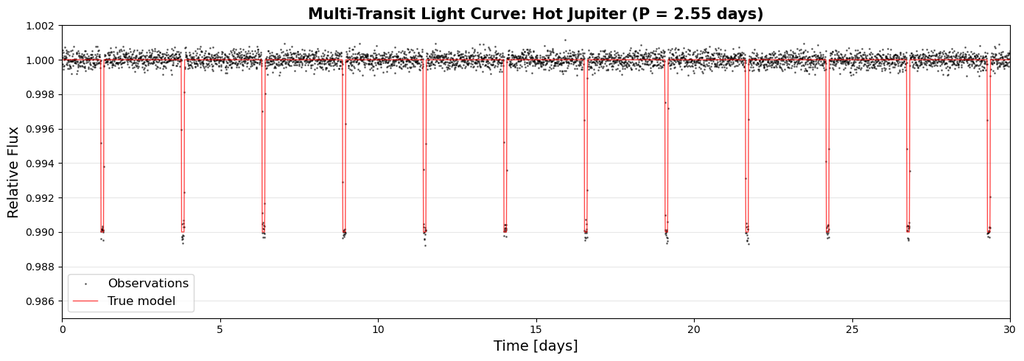

```python
# Plot the full 30-day light curve
plt.figure(figsize=(14, 5))
plt.plot(times_multi, flux_multi_observed, 'k.', markersize=2, alpha=0.5, label='Observations')
plt.plot(times_multi, flux_multi_true, 'r-', linewidth=1, alpha=0.7, label='True model')
plt.xlabel('Time [days]', fontsize=14)
plt.ylabel('Relative Flux', fontsize=14)
plt.title(f'Multi-Transit Light Curve: Hot Jupiter (P = {period} days)', fontsize=15, fontweight='bold')
plt.legend(fontsize=12)
plt.grid(True, alpha=0.3, axis='y')
plt.xlim(0, time_span)
plt.ylim(0.985, 1.002)  # Wider range to show transits and baseline clearly
plt.tight_layout()
plt.show()
```

Notice the difference from our single-transit case! Even though our hot Jupiter has excellent SNR ~ 33 per transit, the 10-minute observing cadence means each individual transit is sampled with only ~15 data points. You can see clear periodic dips around every 2.5 days, but with moderate sampling density. Without knowing the period in advance, identifying the exact periodicity by eye would still be challenging. This is why we need systematic period-finding algorithms.

Our light curve contains 12 transit events over 30 days, each separated by 2.5 days. Even with good signal strength, several challenges emerge in real observations. Moderate sampling: with 10-minute cadence giving ~15 points per 2.5-hour transit, we need multiple transits to build up well-resolved profiles. Gaps are inevitable: real data has missing observations from weather, telescope scheduling, and orbital constraints. Systematics confound the analysis: instrumental effects, stellar activity, and cosmic rays create false signals that can mimic transits. Finally, we face multiple periods: we need to distinguish true planet signals from aliases and systematic artifacts that might appear periodic.

How do we reliably extract the period from this? We need an algorithm that systematically searches for periodic box-shaped signals while accounting for noise. That's exactly what the Box Least Squares (BLS) periodogram does.

## Finding the Period: Box-Least-Squares (BLS)

We have a multi-transit light curve, but we don't know the period. How do we find it? We need an algorithm that systematically searches for periodic signals in noisy time series data. This is fundamentally a periodogram problem—decomposing our data to identify the dominant periodic components.

### Periodograms: Decomposing Signals into Periodic Components

The core idea behind periodograms comes from Fourier analysis: any periodic signal can be decomposed into a sum of simpler periodic functions. You might recall from physics or math that Fourier series express periodic functions as sums of sine and cosine waves:

$$f(t) = a_0 + \sum_{n=1}^{\infty} \left[ a_n \cos\left(\frac{2\pi n t}{P}\right) + b_n \sin\left(\frac{2\pi n t}{P}\right) \right]$$

where the coefficients $a_n$ and $b_n$ measure how much each frequency component contributes. A periodogram tests different trial periods $P$ and calculates the "power" (essentially the squared amplitude of the coefficients) at each period. A large power at some period means the data contains a strong periodic signal at that period.

Classical periodograms use sine and cosine as their basis functions—the building blocks for decomposition. For each trial period, the algorithm essentially asks: "How well can I fit this data with a sine wave at this period?" The answer gives the power at that period.

This works beautifully for smooth, sinusoidal variations like stellar pulsations, binary star orbits, or planetary radial velocity signals. These physical processes naturally produce smooth, wave-like patterns. But transits are different. Look at the transit shape: it's a sharp, rectangular dip—the star's brightness stays constant, drops suddenly during ingress, remains low for the transit duration, then rises suddenly during egress. This is fundamentally a box-shaped signal, not a smooth sine wave.

Trying to fit a sharp box with smooth sine waves is inefficient. Mathematically, you'd need to sum many high-frequency Fourier components to approximate the sharp edges—it's like trying to draw a square with circular arcs. You can do it, but it takes many terms and the fit is never perfect. What if instead we used box-shaped basis functions? For transit detection, the natural approach is: "How well can I fit this data with a periodic box-shaped dip at this period and duration?" This is exactly what Box Least Squares (BLS) does.

### The BLS Approach

BLS systematically tests different periods and durations by:

1. **Phase-folding**: For each trial period $P$, fold all data onto a single representative orbit (phase 0 to 1)
2. **Box fitting**: For each trial duration, divide the phase-folded data into two bins:
   - **In-transit bin**: data points within the assumed transit window
   - **Out-of-transit bin**: all other data points
3. **Power calculation**: Measure how much the mean flux in the in-transit bin differs from the out-of-transit bin

Mathematically, BLS calculates a "signal residue" (SR) that quantifies this difference:

$$\text{SR} = \frac{(\bar{f}_{\rm in} - \bar{f}_{\rm out})^2}{\sigma^2} \times \frac{N_{\rm in} \cdot N_{\rm out}}{N_{\rm total}}$$

This is essentially a signal-to-noise ratio for a box-shaped dip: the squared difference in mean flux between in-transit and out-of-transit bins, normalized by the noise variance, weighted by the number of points in each bin. The SR is maximized when there's a clear, statistically significant dip at the correct period and duration.

Intuitive picture: Imagine testing period $P = 5$ days. BLS phase-folds all your data at this period—all "day 0" observations stack together, all "day 1" observations stack together, etc. Then it tries different transit durations: "What if transits last 2 hours? 3 hours? 4 hours?" For each duration, it divides the folded orbit into an "in-transit" window and "out-of-transit" window, and checks: "Is there a statistically significant dip in the in-transit window?" It repeats this for all periods and durations, finding which combination produces the strongest box-shaped signal.

BLS is optimized for the actual shape of transits—sharp rectangular dips—rather than trying to approximate them with smooth sine waves. This makes it dramatically more sensitive for transit detection. Classical periodograms like Lomb-Scargle will still show power at the transit period (because there is a periodic signal), but BLS produces cleaner, sharper peaks because it's testing the right functional form.

### Implementing BLS

Import the BLS implementation from `astropy.timeseries`:

```python
from astropy.timeseries import BoxLeastSquares
```

Now we need to define the range of transit durations to test. Unlike general periodograms which only need periods to search, BLS also requires knowing possible transit durations since the algorithm must test both period and duration combinations. Transit durations depend on orbital velocity, stellar radius, and impact parameter—they typically range from 1-6 hours for close-in planets around Sun-like stars. Our hot Jupiter has a ~2.5-hour transit. We'll test a range from 0.05 to 0.2 days (1.2 to 4.8 hours) to ensure we don't miss the signal:

```python
# Test transit durations from 0.05 to 0.2 days (1.2 to 4.8 hours)
durations_test = np.linspace(0.05, 0.2, 10)

print(f"Testing {len(durations_test)} different transit durations:")
print(f"  Range: {durations_test[0]*24:.1f} to {durations_test[-1]*24:.1f} hours")
```

```
Testing 10 different transit durations:
  Range: 1.2 to 4.8 hours
```

Now we create the BLS object by providing our time series data along with the measurement uncertainties. The `dy` parameter ensures the algorithm properly weights more precise measurements more heavily in determining the best fit:

```python
# Create BLS object
bls = BoxLeastSquares(times_multi, flux_multi_observed, dy=flux_multi_err)
```

With the BLS object initialized, we run the search using the `autopower` method, which systematically tests all period-duration combinations within our specified range. The `frequency_factor` parameter controls how finely we sample the period space—higher values give more thorough searches at the cost of longer computation time. We also set minimum and maximum period limits based on our data coverage and physical expectations:

```python
# Run BLS
bls_result = bls.autopower(
    durations_test,              # Transit durations to test
    minimum_period=1.0,          # Don't search below 1 day
    maximum_period=15.0,         # Don't search above 15 days
    frequency_factor=2.0         # Grid spacing (2.0 is good default)
)

print(f"\nBLS tested {len(bls_result.period)} different periods")
print(f"Total (period, duration) combinations: {len(bls_result.period) * len(durations_test)}")
```

```
BLS tested 8397 different periods
Total (period, duration) combinations: 83970
```

Now we visualize the BLS periodogram to see how the detection power varies across the tested period range. The periodogram will show a prominent peak at the true orbital period, with the peak height indicating how confident the algorithm is that a periodic transit signal exists at that period:

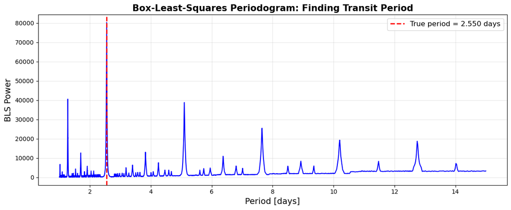

```python
# Extract results
periods_bls = bls_result.period
power_bls = bls_result.power

# Plot BLS periodogram
plt.figure(figsize=(12, 5))
plt.plot(periods_bls, power_bls, 'b-', linewidth=1.5)
plt.axvline(x=period, color='red', linestyle='--', linewidth=2,
           label=f'True period = {period:.3f} days')
plt.xlabel('Period [days]', fontsize=14)
plt.ylabel('BLS Power', fontsize=14)
plt.title('Box-Least-Squares Periodogram: Finding Transit Period', fontsize=15, fontweight='bold')
plt.legend(fontsize=12)
plt.grid(True, alpha=0.3)
plt.tight_layout()
plt.show()
```

With the periodogram calculated, we can extract the best-fit period by finding which tested period produced the highest BLS power. The BLS result also provides the transit epoch (the time of the first transit center), which we'll need for phase folding.

You may notice additional periodic peaks in the periodogram beyond the main peak at the true period. These are aliases—harmonic artifacts that arise because if a signal is truly periodic at period $P$, it is also technically periodic at $2P$, $3P$, etc. (every other transit, every third transit, and so on). However, these longer-period aliases have lower power because they use only a subset of the available transits, resulting in weaker signal-to-noise. Similarly, sub-harmonic aliases at $P/2$, $P/3$ can appear if the box-shaped transit pattern happens to partially align at these shorter periods. The true period is identified as the highest peak, with aliases appearing at lower power at these harmonic and sub-harmonic periods:

```python
# Find best period
best_idx = np.argmax(power_bls)
best_period_bls = periods_bls[best_idx]
best_t0_bls = bls_result.transit_time[best_idx]

print(f"\nBLS Results:")
print(f"  Best period: {best_period_bls:.4f} days")
print(f"  Transit epoch (t0): {best_t0_bls:.4f} days")
print(f"  True period: {period:.4f} days")
print(f"  Error: {abs(best_period_bls - period)*24:.1f} hours")
```

```
BLS Results:
  Best period: 2.5500 days
  Transit epoch (t0): 1.2750 days
  True period: 2.5500 days
  Error: 0.0 hours
```

The BLS correctly identifies the 2.5-day period! The sharp peak at the true period shows that BLS successfully found the periodic transit signal. This period is now the key to unlocking complete physical characterization.

### Phase Folding: Building Up Well-Sampled Transits

Now that we have the period, we can use phase folding to build up a well-sampled transit profile from our sparse observations. Phase folding is the technique of stacking multiple periodic events (in our case, 12 transits) by mapping them onto a common time axis.

The mathematics: For observations at times $t_i$ with period $P$ and reference time $t_0$, we calculate the orbital phase:

$$\phi_i = \frac{(t_i - t_0) \mod P}{P}$$

This maps all observations onto a single "representative orbit" from phase 0 to 1, where phase 0 corresponds to mid-transit. Transits from different orbital cycles stack together at phase 0. Because our 10-minute cadence doesn't align perfectly with the 2.55-day orbital period, each transit's ~15 points fall at slightly different phases. When folded together, these points fill in different parts of the transit curve, creating a much better-sampled profile than any single transit.

Let's implement phase folding to verify the BLS period and dramatically enhance our signal:

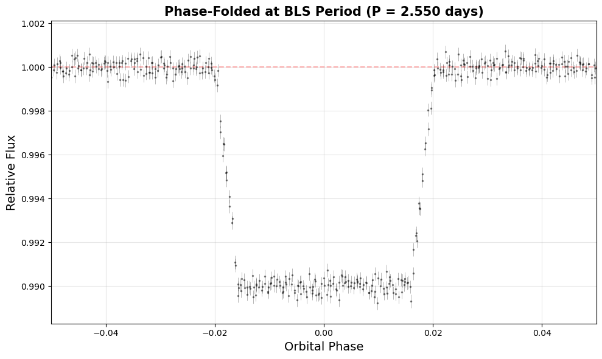

```python
# Phase-fold at BLS period
phases_bls = ((times_multi - best_t0_bls) % best_period_bls) / best_period_bls

# Center at mid-transit
phases_bls = np.where(phases_bls > 0.5, phases_bls - 1, phases_bls)

# Plot phase-folded data
plt.figure(figsize=(10, 6))
plt.errorbar(phases_bls, flux_multi_observed, yerr=flux_multi_err,
             fmt='k.', markersize=3, alpha=0.4, elinewidth=0.5, capsize=0)
plt.xlabel('Orbital Phase', fontsize=14)
plt.ylabel('Relative Flux', fontsize=14)
plt.title(f'Phase-Folded at BLS Period (P = {best_period_bls:.3f} days)',
          fontsize=15, fontweight='bold')
plt.grid(True, alpha=0.3)
plt.axhline(1.0, color='r', linestyle='--', alpha=0.3)
plt.xlim(-0.05, 0.05)
plt.tight_layout()
plt.show()
```

Beautiful! The phase-folded data shows a clear, strong transit centered at phase 0, confirming that BLS found the correct period. The transit depth is now exceptionally well-defined! Notice how the phase-folded transit is excellently sampled with many points—each of the 12 transits contributed ~15 points at slightly different phases, building up a highly detailed transit profile. This is the key benefit of phase folding: transforming moderately-sampled individual transits (~15 points each at 10-minute cadence over a 2.5-hour transit) into an extremely well-resolved combined profile with ~180 points total. The SNR improvement from ~33 to over 100 (via √12 averaging) is a bonus, enabling sub-percent precision on all parameters. Without BLS to find the period, we couldn't phase-fold. Without phase-folding, we'd lack the sampling density and precision needed to measure the transit shape with such exquisite accuracy.

## Complete Physical Characterization with Period

Now that we have the period from BLS and have phase-folded the data to enhance the signal, we can extract the complete physical characterization of our exoplanet. Recall from earlier that the period unlocks the orbital distance (via kinematics) and equilibrium temperature (via energy balance)—parameters that were completely inaccessible from a single transit alone.

### Fitting the Phase-Folded Data

With the signal-to-noise dramatically enhanced through phase folding, we can now fit our trapezoidal transit model to the combined data. The following code will phase-fold all observations at the BLS-detected period, center the phases around mid-transit (phase 0), and prepare the data for fitting. By converting the ~180 phase-folded points into a time-ordered sequence, we can apply the same trapezoidal model we used earlier, but now with much higher precision thanks to the √12 SNR improvement from stacking 12 transits:

```python
# Phase-fold at BLS-detected period
phases_folded = ((times_multi - best_t0_bls) % best_period_bls) / best_period_bls

# Center phase at mid-transit (phase -0.5 to 0.5 instead of 0 to 1)
phases_folded = np.where(phases_folded > 0.5, phases_folded - 1, phases_folded)

# Sort by phase to create ordered phase-folded light curve
sort_indices = np.argsort(phases_folded)
phases_folded = phases_folded[sort_indices]
flux_folded = flux_multi_observed[sort_indices]
flux_folded_err = flux_multi_err[sort_indices]

# Convert phases back to time for fitting (in days)
times_folded = phases_folded * best_period_bls

print(f"Phase-folded {len(times_multi)} points → enhanced SNR by factor ~{np.sqrt(30/period):.1f}")
```

```
Phase-folded 4320 points → enhanced SNR by factor ~3.4
```

With the data phase-folded and signal-to-noise enhanced, we can now fit our trapezoidal transit model. As before, we'll use multiple random starts to ensure we find the global best fit:

```python
# Multiple Random Starts for Phase-Folded Fit
n_tries_folded = 30
results_folded = []

print("Fitting phase-folded data with multiple random starts...")

# Set bounds for folded fit (same as single transit for consistency)
bounds_folded = ([-0.05, 0.0001, 0.05, 0.001], [0.05, 0.05, 0.25, 0.015])

for i in range(n_tries_folded):
    # Generate random initial guesses (observable parameters)
    random_t0 = np.random.uniform(-0.03, 0.03)
    random_depth = np.random.uniform(0.0005, 0.01)
    random_duration = np.random.uniform(0.08, 0.22)
    random_ingress = np.random.uniform(0.002, 0.012)

    p0_random = [random_t0, random_depth, random_duration, random_ingress]

    try:
        popt_try, pcov_try = optimize.curve_fit(
            trapezoidal_transit_model,
            times_folded,
            flux_folded,
            p0=p0_random,
            sigma=flux_folded_err,
            absolute_sigma=True,
            bounds=bounds_folded,
            maxfev=10000
        )

        # Calculate chi-squared
        model_try = trapezoidal_transit_model(times_folded, *popt_try)
        chi_sq = np.sum(((flux_folded - model_try) / flux_folded_err)**2)

        results_folded.append({
            'chi_squared': chi_sq,
            'fitted_params': popt_try,
            'covariance': pcov_try,
            'success': True
        })

    except Exception as e:
        results_folded.append({'success': False})

# Find best result
successful_folded = [r for r in results_folded if r.get('success', False)]

if len(successful_folded) > 0:
    best_folded = min(successful_folded, key=lambda x: x['chi_squared'])
    chi_sq_vals_folded = [r['chi_squared'] for r in successful_folded]

    popt_folded = best_folded['fitted_params']
    pcov_folded = best_folded['covariance']
    t0_folded, depth_folded, duration_folded, ingress_folded = popt_folded
    errors_folded = np.sqrt(np.diag(pcov_folded))

    print(f"\n{len(successful_folded)}/{n_tries_folded} fits succeeded")
    print(f"χ² range: [{min(chi_sq_vals_folded):.1f}, {max(chi_sq_vals_folded):.1f}]")
    print(f"Best χ² = {best_folded['chi_squared']:.1f}")

    print("\nFitted Observable Parameters (Phase-Folded Data - Best of 30):")
    print("="*60)
    print(f"t0           = {t0_folded:10.6f} ± {errors_folded[0]:.6f} days")
    print(f"Depth        = {depth_folded:10.6f} ± {errors_folded[1]:.6f} ({depth_folded*1e6:.0f} ± {errors_folded[1]*1e6:.0f} ppm)")
    print(f"Duration     = {duration_folded:10.6f} ± {errors_folded[2]:.6f} days")
    print(f"Ingress dur  = {ingress_folded:10.6f} ± {errors_folded[3]:.6f} days")
else:
    print(f"\nWARNING: No fits succeeded!")
```

```
Fitting phase-folded data with multiple random starts...
```

```
30/30 fits succeeded
χ² range: [4319.6, 4319.6]
Best χ² = 4319.6

Fitted Observable Parameters (Phase-Folded Data - Best of 30):
============================================================
t0           =   0.000316 ± 0.000054 days
Depth        =   0.009985 ± 0.000025 (9985 ± 25 ppm)
Duration     =   0.102352 ± 0.000225 days
Ingress dur  =   0.010698 ± 0.000200 days
```

The uncertainties from phase-folded data are much smaller than from a single transit because we've combined multiple transits! Let's verify that we can recover the original orbital velocity from these fitted parameters:

```python
print("\nRecovering Physical Parameters from Phase-Folded Observables:")
print("="*70)

# 1. Planet-to-star radius ratio from depth
rp_rs_folded_recovered = np.sqrt(depth_folded)
print(f"\n1. Planet-to-star radius ratio:")
print(f"   Rp/Rs = sqrt(depth) = sqrt({depth_folded:.6f}) = {rp_rs_folded_recovered:.4f}")
print(f"   True value: {rp_rs:.4f}")
print(f"   Recovery error: {abs(rp_rs_folded_recovered - rp_rs)/rp_rs * 100:.2f}%")

# 2. Impact parameter from duration and ingress
sqrt_1_minus_b2_folded = rp_rs_folded_recovered * duration_folded / ingress_folded
sqrt_1_minus_b2_folded = min(sqrt_1_minus_b2_folded, 0.9999)
b_folded_recovered = np.sqrt(1 - sqrt_1_minus_b2_folded**2)
print(f"\n2. Impact parameter:")
print(f"   From T_ingress/T_total ratio: {ingress_folded/duration_folded:.4f}")
print(f"   sqrt(1-b²) = {sqrt_1_minus_b2_folded:.4f}")
print(f"   b = {b_folded_recovered:.3f}")
print(f"   True value: {impact_param:.3f}")
print(f"   Recovery error: {abs(b_folded_recovered - impact_param):.3f}")

# 3. Orbital velocity
chord_recovered_folded = 2 * R_star_sim * sqrt_1_minus_b2_folded
duration_recovered_folded = duration_folded * u.day
v_recovered_folded = (chord_recovered_folded / duration_recovered_folded).to(u.km / u.s)
print(f"\n3. Orbital velocity:")
print(f"   Formula: v = 2*R*×sqrt(1-b²) / T_total")
print(f"   R* = {R_star_sim.value:.0f} km")
print(f"   sqrt(1-b²) = {sqrt_1_minus_b2_folded:.4f}")
print(f"   chord = 2*{R_star_sim.value:.0f}*{sqrt_1_minus_b2_folded:.4f} = {chord_recovered_folded.value:.0f} km")
print(f"   T_total = {duration_folded:.6f} days = {duration_recovered_folded.to(u.s).value:.0f} s")
print(f"   v = {chord_recovered_folded.value:.0f}/{duration_recovered_folded.to(u.s).value:.0f} = {v_recovered_folded.value:.2f} km/s")
print(f"   True value: {orbital_velocity.value:.2f} km/s")
print(f"   Error: {abs(v_recovered_folded - orbital_velocity).value:.2f} km/s ({abs(v_recovered_folded - orbital_velocity).value/orbital_velocity.value * 100:.2f}%)")

print("\n--- SUMMARY ---")
print(f"Rp/Rs = sqrt({depth_folded:.6f}) = {rp_rs_folded_recovered:.4f} (true: {rp_rs:.4f})")
print(f"Impact parameter b = {b_folded_recovered:.3f} (true: {impact_param:.3f})")
print(f"Orbital velocity = {v_recovered_folded.value:.2f} km/s (true: {orbital_velocity.value:.2f} km/s)")
```

```
Recovering Physical Parameters from Phase-Folded Observables:
======================================================================

1. Planet-to-star radius ratio:
   Rp/Rs = sqrt(depth) = sqrt(0.009985) = 0.0999
   True value: 0.1000
   Recovery error: 0.08%

2. Impact parameter:
   From T_ingress/T_total ratio: 0.1045
   sqrt(1-b²) = 0.9560
   b = 0.293
   True value: 0.300
   Recovery error: 0.007

3. Orbital velocity:
   Formula: v = 2*R*×sqrt(1-b²) / T_total
   R* = 695700 km
   sqrt(1-b²) = 0.9560
   chord = 2*695700*0.9560 = 1330212 km
   T_total = 0.102352 days = 8843 s
   v = 1330212/8843 = 150.42 km/s
   True value: 150.00 km/s
   Error: 0.42 km/s (0.28%)

--- SUMMARY ---
Rp/Rs = sqrt(0.009985) = 0.0999 (true: 0.1000)
Impact parameter b = 0.293 (true: 0.300)
Orbital velocity = 150.42 km/s (true: 150.00 km/s)
```

Excellent! The phase-folded data yields even more precise recovery of the orbital velocity due to the improved parameter uncertainties from combining multiple transits.

### Deriving All Physical Parameters

With the fitted parameters from phase-folded data and the BLS-detected period, we can now calculate all the physical parameters we discussed earlier. As explained above, the period unlocks the semi-major axis (via kinematics) and equilibrium temperature (via energy balance).

**Planet Radius**: From the fitted $R_p/R_\star$ ratio (with better precision from phase-folding):

```python
# Assume Sun-like star
R_star = const.R_sun.to(u.km)
M_star = const.M_sun  # Solar mass

# Planet radius from recovered Rp/Rs
R_planet = rp_rs_folded_recovered * R_star
R_planet_earth = (R_planet / const.R_earth.to(u.km)).value
R_planet_jupiter = (R_planet / const.R_jup.to(u.km)).value

print("\n" + "="*70)
print("COMPLETE EXOPLANET CHARACTERIZATION")
print("="*70)
print("\n1. PLANET RADIUS")
print("-"*70)
print(f"Recovered Rp/Rs: {rp_rs_folded_recovered:.4f}")
print(f"Planet radius: {R_planet.value:.0f} km = {R_planet_earth:.2f} R_Earth = {R_planet_jupiter:.2f} R_Jupiter")
```

```
======================================================================
COMPLETE EXOPLANET CHARACTERIZATION
======================================================================

1. PLANET RADIUS
----------------------------------------------------------------------
Recovered Rp/Rs: 0.0999
Planet radius: 69516 km = 10.90 R_Earth = 0.97 R_Jupiter
```

**Orbital Velocity**: From the transit duration and recovered impact parameter using $v = 2R_\star\sqrt{1-b^2} / t_{\rm transit}$:

```python
# Use the recovered orbital velocity we calculated above
v_orbit = v_recovered_folded

print("\n2. ORBITAL VELOCITY")
print("-"*70)
print(f"Impact parameter: b = {b_folded_recovered:.3f}")
print(f"Transit duration: {duration_folded:.4f} days = {(duration_folded*u.day).to(u.hour).value:.2f} hours")
print(f"Chord length: {chord_recovered_folded.value:.0f} km")
print(f"Orbital velocity: {v_orbit.value:.1f} km/s")
```

```
2. ORBITAL VELOCITY
----------------------------------------------------------------------
Impact parameter: b = 0.293
Transit duration: 0.1024 days = 2.46 hours
Chord length: 1330212 km
Orbital velocity: 150.4 km/s
```

**Semi-major Axis**: Using kinematics—the planet travels one complete orbit in time $P$, so the circumference is $2\pi a = vP$, giving

$$a = vP/(2\pi)$$

```python
# Calculate orbital distance from velocity and period (a = vP/2π)
P_orbit_quantity = best_period_bls * u.day
a_orbit = v_orbit * P_orbit_quantity / (2 * np.pi)
a_orbit_AU = a_orbit.to(u.AU)

print("\n3. SEMI-MAJOR AXIS")
print("-"*70)
print(f"Period: {best_period_bls:.4f} days")
print(f"Orbital velocity: {v_orbit.value:.1f} km/s")
print(f"Semi-major axis: a = {a_orbit_AU.value:.4f} AU")
print(f"(Mercury orbits at 0.39 AU → this planet is {a_orbit_AU.value/0.39:.1f}× closer!)")
```

```
3. SEMI-MAJOR AXIS
----------------------------------------------------------------------
Period: 2.5500 days
Orbital velocity: 150.4 km/s
Semi-major axis: a = 0.0353 AU
(Mercury orbits at 0.39 AU → this planet is 0.1× closer!)
```

**Equilibrium Temperature**: From energy balance using the formula we derived earlier and assuming an albedo of 0.3,

$$T_{\rm eq} = T_\star \sqrt{R_\star/(2a)} (1-A)^{1/4}$$

```python
# Stellar parameters
T_star = 5778 * u.K  # Solar temperature
albedo = 0.3  # Typical for gas giants

# Calculate equilibrium temperature
# T_eq = T_star * sqrt(R_star / (2*a)) * (1-albedo)^(1/4)
R_star_m = R_star.to(u.m)
a_orbit_m = a_orbit_AU.to(u.m)
T_eq = T_star * np.sqrt((R_star_m / (2 * a_orbit_m)).value) * (1 - albedo)**0.25

# Calculate stellar flux at planet
L_sun = const.L_sun  # Solar luminosity
F_earth = L_sun / (4 * np.pi * const.au**2)  # Flux at 1 AU
F_planet = F_earth * (const.au / a_orbit_m)**2  # Flux at planet's distance

print("\n4. EQUILIBRIUM TEMPERATURE")
print("-"*70)
print(f"Stellar flux at Earth (1 AU): {F_earth.to(u.W / u.m**2).value:.0f} W/m²")
print(f"Stellar flux at planet: {F_planet.to(u.W / u.m**2).value:.0f} W/m²")
print(f"Intensity ratio: {(F_planet/F_earth).value:.0f}×")
print(f"Equilibrium temperature: {T_eq.value:.0f} K = {(T_eq.value-273.15):.0f}°C")
print(f"(Hot enough to vaporize metals!)")
```

```
4. EQUILIBRIUM TEMPERATURE
----------------------------------------------------------------------
Stellar flux at Earth (1 AU): 1361 W/m²
Stellar flux at planet: 1094989 W/m²
Intensity ratio: 804×
Equilibrium temperature: 1357 K = 1084°C
(Hot enough to vaporize metals!)
```

**Bringing It All Together**: We've now derived every major physical parameter for this exoplanet system from our transit photometry alone. Let's summarize what we've accomplished: starting from raw brightness measurements showing tiny periodic dips, we used BLS to find the period, phase folding to enhance the signal, curve fitting to extract geometric parameters, and physics calculations to convert those into physical properties. This complete characterization demonstrates the remarkable power of transit surveys:

```python
print("\n" + "="*70)
print("SUMMARY: COMPLETE EXOPLANET CHARACTERIZATION")
print("="*70)
print(f"Planet radius:      {R_planet_earth:.1f} R_Earth (Hot Jupiter)")
print(f"Orbital distance:   {a_orbit_AU:.4f} AU ({a_orbit_AU/0.39:.1f}× closer than Mercury)")
print(f"Orbital period:     {best_period_bls:.2f} days")
print(f"Orbital velocity:   {v_orbit:.0f} km/s ({v_orbit/30:.0f}× Earth's speed)")
print(f"Equilibrium temp:   {T_eq:.0f} K (molten rock conditions)")
```

```
======================================================================
SUMMARY: COMPLETE EXOPLANET CHARACTERIZATION
======================================================================
Planet radius:      10.9 R_Earth (Hot Jupiter)
Orbital distance:   0.0353 AU AU (0.1 AU× closer than Mercury)
Orbital period:     2.55 days
Orbital velocity:   150 km / s km/s (5 km / s× Earth's speed)
Equilibrium temp:   1357 K K (molten rock conditions)
```

## Important Caveats

Throughout this lecture, we've worked with a hot Jupiter to demonstrate the analysis techniques. This represents the type of planet that dominated early transit discoveries due to their large size (producing deep transits) and short periods (allowing quick confirmation). However, there are additional effects and refinements that become important for high-precision characterization and for detecting smaller planets like Neptunes and Super-Earths.

### Limb Darkening

Stars are not uniformly bright across their disk—they exhibit limb darkening, appearing darker near their edges than at their centers. This is a fundamental consequence of stellar atmospheric structure. When you look at the center of a star's disk, you're seeing deeper, hotter layers of the atmosphere where temperatures are higher and radiation is more intense. Near the limb (edge), you're viewing the atmosphere at a grazing angle, seeing only the cooler, less luminous surface layers. You can actually see this effect on the Sun—photographs show the solar disk is noticeably darker near the edges.

When a planet transits across different parts of the stellar disk, it blocks regions of different brightness. A planet crossing the bright center blocks more light than one grazing the dim limb. This creates smoother, more rounded ingress and egress curves than the linear slopes our trapezoidal model predicts. The effect is most significant for grazing transits (high impact parameter $b$) where the planet spends much time near the darkened limb. For moderately central transits like our example, the trapezoidal model works well.

For high-precision work or when studying grazing transits, astronomers use more sophisticated models that incorporate limb darkening through additional parameters (typically two coefficients that describe how brightness falls off from center to edge). These models are implemented in specialized packages like `batman` or `pytransit`. Our trapezoidal model captures the essential physics, and the curve-fitting principles you've learned remain the same—more sophisticated models just add more parameters to fit!

### Stellar Activity

Throughout this lecture, we've assumed that periodic brightness variations are caused by transiting planets. In reality, stellar activity is one of the most challenging confounding factors in exoplanet detection. Stars are not constant light sources—they vary in brightness due to magnetic activity on their surfaces.

Starspots are dark regions (analogous to sunspots) caused by concentrated magnetic fields that suppress convection and reduce local temperature. As the star rotates, spots moving in and out of view cause periodic brightness changes. A large starspot group transiting across the stellar disk can produce periodic dips that look remarkably similar to a planet transit! Faculae are bright regions associated with magnetic activity that increase stellar brightness, which can complicate or partially mask transit signals. Most stars rotate with periods of days to weeks, creating rotationally modulated brightness variations as these features rotate in and out of view.

Distinguishing a planet transit from a large starspot is difficult because both produce periodic dips in brightness with similar timescales and amplitudes. However, there are key differences astronomers exploit. Spots evolve on timescales of weeks to months, so their signals change over time, while planet transits remain stable. Spots typically produce different shapes (often less symmetric and with evolving profiles) compared to the clean, repeatable shapes of planetary transits. Multi-wavelength observations help because spots have different spectral signatures than transits (spots affect bluer wavelengths more). Follow-up observations including radial velocity measurements, transit timing variations, and careful analysis of light curve asymmetries help confirm the planetary nature of candidate signals.

Modeling stellar activity is now a major focus of exoplanet research, especially for finding Earth-sized planets around active stars where the planet signal can be comparable to or smaller than stellar variability. The techniques you've learned in this lecture (BLS, phase folding, curve fitting) are essential tools, but real exoplanet detection requires careful vetting to distinguish true planets from stellar activity false positives. The cross-disciplinary study of stars and planets—understanding how stellar variability affects planet detection—represents one of the most active and challenging areas in contemporary astronomy, making confirmed exoplanet discoveries all the more remarkable!

## Summary

### Key Concepts

In this lecture, you've learned:

- **The Complementary Nature of RV and Transit Methods**: Understanding that radial velocity measures stellar wobble from Doppler shifts (requiring spectroscopy, giving mass) while transits detect periodic dimming (requiring photometry, giving radius). Combined, they provide mass and radius for density and composition determination. RV favors massive planets while transits favor large planets, with synergy enabling complete characterization
- **Transit Physics and Geometry**: Learning that transit depth $(R_p/R_\star)^2$ directly measures the planet-to-star radius ratio as a geometric effect. Understanding how duration depends on orbital velocity and impact parameter. Calculating that closer planets have higher transit probabilities ($P \approx R_\star/a$), explaining why hot Jupiters dominated early discoveries—not because they're common, but because they're geometrically favored
- **Single Transit Analysis with Curve Fitting**: Using `scipy.optimize.curve_fit` to fit trapezoidal transit models capturing ingress and egress slopes from finite planet size. Extracting planet radius and orbital velocity from one transit without knowing the period. Evaluating fit quality through reduced chi-squared and verifying parameter uncertainties from covariance matrices
- **Period Finding with Box-Least-Squares**: Understanding how BLS systematically searches for periodic box-shaped dips, optimized for transit geometry. Unlike general periodograms searching for sinusoids, BLS tests actual box shapes matching transits. Using `astropy.timeseries.BoxLeastSquares` to detect periods, confirming signals are periodic rather than noise
- **Phase Folding to Build Up Well-Sampled Transits**: Learning that stacking multiple transits at the correct period builds up detailed transit profiles from moderately-cadenced observations. Understanding the mathematics where observations map onto a representative orbit using $\phi_i = [(t_i - t_0) \mod P]/P$. With realistic 10-minute cadence giving ~15 points per 2.5-hour transit, phase folding combines points from 12 transits at different phases to create an extremely well-resolved combined profile with ~180 total points. The SNR improvement by $\sqrt{N}$ provides a bonus precision boost—our hot Jupiter's already-excellent SNR ~ 33 per transit becomes SNR > 100 after phase-folding 12 transits, enabling sub-percent parameter precision
- **Complete Physical Characterization**: Deriving planet radius from fitted ratio, velocity from duration, and semi-major axis from period using kinematics ($a = vP/2\pi$). Using the orbital distance to calculate equilibrium temperature from energy balance. The period unlocks parameters inaccessible from single transits, transforming brightness measurements into complete planetary portraits
- **Observational Refinements and Confounding Factors**: Recognizing that limb darkening affects transit shapes especially for grazing geometries, requiring sophisticated models for high precision. Understanding that stellar activity including starspots can mimic transit signals, making careful vetting essential to distinguish true planets from false positives

### What You Can Now Do

After working through this material, you should be able to:

- Simulate realistic transit observations with trapezoidal models that capture ingress and egress physics
- Fit transit models to noisy photometric data using `scipy.optimize.curve_fit` to extract best-fit parameters and uncertainties
- Implement the Box-Least-Squares algorithm using `astropy.timeseries` to detect orbital periods in multi-transit time series
- Apply phase folding techniques to stack multiple transits and build up well-sampled transit profiles from sparse observations
- Derive complete physical characterizations including planet radius, semi-major axis, and equilibrium temperature from fitted parameters and known stellar properties
- Use `astropy.units` and `astropy.constants` for proper unit handling in astronomical calculations
- Evaluate fit quality through reduced chi-squared statistics and residual analysis
- Recognize the observational challenges including geometric alignment probabilities and stellar activity confounders

These are the same curve-fitting and time series analysis techniques used in major transit surveys including Kepler, TESS, and ground-based searches that have discovered thousands of exoplanets.

### Looking Ahead

You now have the statistical foundation from Lecture 17 and the curve-fitting skills from Lecture 18, which you've applied to time series analysis in this lecture. The techniques you've learned extend far beyond exoplanet transits—similar methods reveal stellar pulsations in variable stars, binary orbits from radial velocities, and internal stellar structure through asteroseismology. The curve-fitting and time series analysis skills you've learned are fundamental to astronomical research—every exoplanet parameter reported in scientific papers derives from fitting models to data using techniques like those in this lecture. You now possess the computational tools to transform photometric observations into physical understanding, turning light into knowledge about distant worlds.